# wrangle_act

```python
import pandas as pd
import requests
import tweepy
import numpy as np
import matplotlib.pyplot as plt
import json
import time
from datetime import datetime
```

### Gathering the Data

```python
twitter_archive = pd.read_csv('twitter-archive-enhanced.csv')
twitter_archive.head(50)
```

|  | tweet_id | in_reply_to_status_id | in_reply_to_user_id | timestamp | source | text | retweeted_status_id | retweeted_status_user_id | retweeted_status_timestamp | expanded_urls | rating_numerator | rating_denominator | name | doggo | floofer | pupper | puppo |
| --- | --- | --- | --- | --- | --- | --- | --- | --- | --- | --- | --- | --- | --- | --- | --- | --- | --- |
| 0 | 892420643555336193 | NaN | NaN | 2017-08-01 16:23:56 +0000 | <a href="http://twitter.com/download/iphone" rel="nofollow">Twitter for iPhone</a> | This is Phineas. He's a mystical boy. Only ever appears in the hole of a donut. 13/10 https://t.co/MgUWQ76dJU | NaN | NaN | NaN | https://twitter.com/dog_rates/status/892420643555336193/photo/1 | 13 | 10 | Phineas | None | None | None | None |
| 1 | 892177421306343426 | NaN | NaN | 2017-08-01 00:17:27 +0000 | <a href="http://twitter.com/download/iphone" rel="nofollow">Twitter for iPhone</a> | This is Tilly. She's just checking pup on you. Hopes you're doing ok. If not, she's available for pats, snugs, boops, the whole bit. 13/10 https://t.co/0Xxu71qeIV | NaN | NaN | NaN | https://twitter.com/dog_rates/status/892177421306343426/photo/1 | 13 | 10 | Tilly | None | None | None | None |
| 2 | 891815181378084864 | NaN | NaN | 2017-07-31 00:18:03 +0000 | <a href="http://twitter.com/download/iphone" rel="nofollow">Twitter for iPhone</a> | This is Archie. He is a rare Norwegian Pouncing Corgo. Lives in the tall grass. You never know when one may strike. 12/10 https://t.co/wUnZnhtVJB | NaN | NaN | NaN | https://twitter.com/dog_rates/status/891815181378084864/photo/1 | 12 | 10 | Archie | None | None | None | None |
| 3 | 891689557279858688 | NaN | NaN | 2017-07-30 15:58:51 +0000 | <a href="http://twitter.com/download/iphone" rel="nofollow">Twitter for iPhone</a> | This is Darla. She commenced a snooze mid meal. 13/10 happens to the best of us https://t.co/tD36da7qLQ | NaN | NaN | NaN | https://twitter.com/dog_rates/status/891689557279858688/photo/1 | 13 | 10 | Darla | None | None | None | None |
| 4 | 891327558926688256 | NaN | NaN | 2017-07-29 16:00:24 +0000 | <a href="http://twitter.com/download/iphone" rel="nofollow">Twitter for iPhone</a> | This is Franklin. He would like you to stop calling him "cute." He is a very fierce shark and should be respected as such. 12/10 #BarkWeek https://t.co/AtUZn91f7f | NaN | NaN | NaN | https://twitter.com/dog_rates/status/891327558926688256/photo/1,https://twitter.com/dog_rates/status/891327558926688256/photo/1 | 12 | 10 | Franklin | None | None | None | None |
| 5 | 891087950875897856 | NaN | NaN | 2017-07-29 00:08:17 +0000 | <a href="http://twitter.com/download/iphone" rel="nofollow">Twitter for iPhone</a> | Here we have a majestic great white breaching off South Africa's coast. Absolutely h*ckin breathtaking. 13/10 (IG: tucker_marlo) #BarkWeek https://t.co/kQ04fDDRmh | NaN | NaN | NaN | https://twitter.com/dog_rates/status/891087950875897856/photo/1 | 13 | 10 | None | None | None | None | None |
| 6 | 890971913173991426 | NaN | NaN | 2017-07-28 16:27:12 +0000 | <a href="http://twitter.com/download/iphone" rel="nofollow">Twitter for iPhone</a> | Meet Jax. He enjoys ice cream so much he gets nervous around it. 13/10 help Jax enjoy more things by clicking below\n\nhttps://t.co/Zr4hWfAs1H https://t.co/tVJBRMnhxl | NaN | NaN | NaN | https://gofundme.com/ydvmve-surgery-for-jax,https://twitter.com/dog_rates/status/890971913173991426/photo/1 | 13 | 10 | Jax | None | None | None | None |
| 7 | 890729181411237888 | NaN | NaN | 2017-07-28 00:22:40 +0000 | <a href="http://twitter.com/download/iphone" rel="nofollow">Twitter for iPhone</a> | When you watch your owner call another dog a good boy but then they turn back to you and say you're a great boy. 13/10 https://t.co/v0nONBcwxq | NaN | NaN | NaN | https://twitter.com/dog_rates/status/890729181411237888/photo/1,https://twitter.com/dog_rates/status/890729181411237888/photo/1 | 13 | 10 | None | None | None | None | None |
| 8 | 890609185150312448 | NaN | NaN | 2017-07-27 16:25:51 +0000 | <a href="http://twitter.com/download/iphone" rel="nofollow">Twitter for iPhone</a> | This is Zoey. She doesn't want to be one of the scary sharks. Just wants to be a snuggly pettable boatpet. 13/10 #BarkWeek https://t.co/9TwLuAGH0b | NaN | NaN | NaN | https://twitter.com/dog_rates/status/890609185150312448/photo/1 | 13 | 10 | Zoey | None | None | None | None |
| 9 | 890240255349198849 | NaN | NaN | 2017-07-26 15:59:51 +0000 | <a href="http://twitter.com/download/iphone" rel="nofollow">Twitter for iPhone</a> | This is Cassie. She is a college pup. Studying international doggo communication and stick theory. 14/10 so elegant much sophisticate https://t.co/t1bfwz5S2A | NaN | NaN | NaN | https://twitter.com/dog_rates/status/890240255349198849/photo/1 | 14 | 10 | Cassie | doggo | None | None | None |
| 10 | 890006608113172480 | NaN | NaN | 2017-07-26 00:31:25 +0000 | <a href="http://twitter.com/download/iphone" rel="nofollow">Twitter for iPhone</a> | This is Koda. He is a South Australian deckshark. Deceptively deadly. Frighteningly majestic. 13/10 would risk a petting #BarkWeek https://t.co/dVPW0B0Mme | NaN | NaN | NaN | https://twitter.com/dog_rates/status/890006608113172480/photo/1,https://twitter.com/dog_rates/status/890006608113172480/photo/1 | 13 | 10 | Koda | None | None | None | None |
| 11 | 889880896479866881 | NaN | NaN | 2017-07-25 16:11:53 +0000 | <a href="http://twitter.com/download/iphone" rel="nofollow">Twitter for iPhone</a> | This is Bruno. He is a service shark. Only gets out of the water to assist you. 13/10 terrifyingly good boy https://t.co/u1XPQMl29g | NaN | NaN | NaN | https://twitter.com/dog_rates/status/889880896479866881/photo/1 | 13 | 10 | Bruno | None | None | None | None |
| 12 | 889665388333682689 | NaN | NaN | 2017-07-25 01:55:32 +0000 | <a href="http://twitter.com/download/iphone" rel="nofollow">Twitter for iPhone</a> | Here's a puppo that seems to be on the fence about something haha no but seriously someone help her. 13/10 https://t.co/BxvuXk0UCm | NaN | NaN | NaN | https://twitter.com/dog_rates/status/889665388333682689/photo/1 | 13 | 10 | None | None | None | None | puppo |
| 13 | 889638837579907072 | NaN | NaN | 2017-07-25 00:10:02 +0000 | <a href="http://twitter.com/download/iphone" rel="nofollow">Twitter for iPhone</a> | This is Ted. He does his best. Sometimes that's not enough. But it's ok. 12/10 would assist https://t.co/f8dEDcrKSR | NaN | NaN | NaN | https://twitter.com/dog_rates/status/889638837579907072/photo/1,https://twitter.com/dog_rates/status/889638837579907072/photo/1 | 12 | 10 | Ted | None | None | None | None |
| 14 | 889531135344209921 | NaN | NaN | 2017-07-24 17:02:04 +0000 | <a href="http://twitter.com/download/iphone" rel="nofollow">Twitter for iPhone</a> | This is Stuart. He's sporting his favorite fanny pack. Secretly filled with bones only. 13/10 puppared puppo #BarkWeek https://t.co/y70o6h3isq | NaN | NaN | NaN | https://twitter.com/dog_rates/status/889531135344209921/photo/1 | 13 | 10 | Stuart | None | None | None | puppo |
| 15 | 889278841981685760 | NaN | NaN | 2017-07-24 00:19:32 +0000 | <a href="http://twitter.com/download/iphone" rel="nofollow">Twitter for iPhone</a> | This is Oliver. You're witnessing one of his many brutal attacks. Seems to be playing with his victim. 13/10 fr*ckin frightening #BarkWeek https://t.co/WpHvrQedPb | NaN | NaN | NaN | https://twitter.com/dog_rates/status/889278841981685760/video/1 | 13 | 10 | Oliver | None | None | None | None |
| 16 | 888917238123831296 | NaN | NaN | 2017-07-23 00:22:39 +0000 | <a href="http://twitter.com/download/iphone" rel="nofollow">Twitter for iPhone</a> | This is Jim. He found a fren. Taught him how to sit like the good boys. 12/10 for both https://t.co/chxruIOUJN | NaN | NaN | NaN | https://twitter.com/dog_rates/status/888917238123831296/photo/1 | 12 | 10 | Jim | None | None | None | None |
| 17 | 888804989199671297 | NaN | NaN | 2017-07-22 16:56:37 +0000 | <a href="http://twitter.com/download/iphone" rel="nofollow">Twitter for iPhone</a> | This is Zeke. He has a new stick. Very proud of it. Would like you to throw it for him without taking it. 13/10 would do my best https://t.co/HTQ77yNQ5K | NaN | NaN | NaN | https://twitter.com/dog_rates/status/888804989199671297/photo/1,https://twitter.com/dog_rates/status/888804989199671297/photo/1 | 13 | 10 | Zeke | None | None | None | None |
| 18 | 888554962724278272 | NaN | NaN | 2017-07-22 00:23:06 +0000 | <a href="http://twitter.com/download/iphone" rel="nofollow">Twitter for iPhone</a> | This is Ralphus. He's powering up. Attempting maximum borkdrive. 13/10 inspirational af https://t.co/YnYAFCTTiK | NaN | NaN | NaN | https://twitter.com/dog_rates/status/888554962724278272/photo/1,https://twitter.com/dog_rates/status/888554962724278272/photo/1,https://twitter.com/dog_rates/status/888554962724278272/photo/1,https://… | 13 | 10 | Ralphus | None | None | None | None |
| 19 | 888202515573088257 | NaN | NaN | 2017-07-21 01:02:36 +0000 | <a href="http://twitter.com/download/iphone" rel="nofollow">Twitter for iPhone</a> | RT @dog_rates: This is Canela. She attempted some fancy porch pics. They were unsuccessful. 13/10 someone help her https://t.co/cLyzpcUcMX | 8.874740e+17 | 4.196984e+09 | 2017-07-19 00:47:34 +0000 | https://twitter.com/dog_rates/status/887473957103951883/photo/1,https://twitter.com/dog_rates/status/887473957103951883/photo/1,https://twitter.com/dog_rates/status/887473957103951883/photo/1,https://… | 13 | 10 | Canela | None | None | None | None |
| 20 | 888078434458587136 | NaN | NaN | 2017-07-20 16:49:33 +0000 | <a href="http://twitter.com/download/iphone" rel="nofollow">Twitter for iPhone</a> | This is Gerald. He was just told he didn't get the job he interviewed for. A h*ckin injustice. 12/10 didn't want the job anyway https://t.co/DK7iDPfuRX | NaN | NaN | NaN | https://twitter.com/dog_rates/status/888078434458587136/photo/1,https://twitter.com/dog_rates/status/888078434458587136/photo/1 | 12 | 10 | Gerald | None | None | None | None |
| 21 | 887705289381826560 | NaN | NaN | 2017-07-19 16:06:48 +0000 | <a href="http://twitter.com/download/iphone" rel="nofollow">Twitter for iPhone</a> | This is Jeffrey. He has a monopoly on the pool noodles. Currently running a 'boop for two' midweek sale. 13/10 h*ckin strategic https://t.co/PhrUk20Q64 | NaN | NaN | NaN | https://twitter.com/dog_rates/status/887705289381826560/photo/1 | 13 | 10 | Jeffrey | None | None | None | None |
| 22 | 887517139158093824 | NaN | NaN | 2017-07-19 03:39:09 +0000 | <a href="http://twitter.com/download/iphone" rel="nofollow">Twitter for iPhone</a> | I've yet to rate a Venezuelan Hover Wiener. This is such an honor. 14/10 paw-inspiring af (IG: roxy.thedoxy) https://t.co/20VrLAA8ba | NaN | NaN | NaN | https://twitter.com/dog_rates/status/887517139158093824/video/1 | 14 | 10 | such | None | None | None | None |
| 23 | 887473957103951883 | NaN | NaN | 2017-07-19 00:47:34 +0000 | <a href="http://twitter.com/download/iphone" rel="nofollow">Twitter for iPhone</a> | This is Canela. She attempted some fancy porch pics. They were unsuccessful. 13/10 someone help her https://t.co/cLyzpcUcMX | NaN | NaN | NaN | https://twitter.com/dog_rates/status/887473957103951883/photo/1,https://twitter.com/dog_rates/status/887473957103951883/photo/1 | 13 | 10 | Canela | None | None | None | None |
| 24 | 887343217045368832 | NaN | NaN | 2017-07-18 16:08:03 +0000 | <a href="http://twitter.com/download/iphone" rel="nofollow">Twitter for iPhone</a> | You may not have known you needed to see this today. 13/10 please enjoy (IG: emmylouroo) https://t.co/WZqNqygEyV | NaN | NaN | NaN | https://twitter.com/dog_rates/status/887343217045368832/video/1 | 13 | 10 | None | None | None | None | None |
| 25 | 887101392804085760 | NaN | NaN | 2017-07-18 00:07:08 +0000 | <a href="http://twitter.com/download/iphone" rel="nofollow">Twitter for iPhone</a> | This... is a Jubilant Antarctic House Bear. We only rate dogs. Please only send dogs. Thank you... 12/10 would suffocate in floof https://t.co/4Ad1jzJSdp | NaN | NaN | NaN | https://twitter.com/dog_rates/status/887101392804085760/photo/1 | 12 | 10 | None | None | None | None | None |
| 26 | 886983233522544640 | NaN | NaN | 2017-07-17 16:17:36 +0000 | <a href="http://twitter.com/download/iphone" rel="nofollow">Twitter for iPhone</a> | This is Maya. She's very shy. Rarely leaves her cup. 13/10 would find her an environment to thrive in https://t.co/I6oNy0CgiT | NaN | NaN | NaN | https://twitter.com/dog_rates/status/886983233522544640/photo/1,https://twitter.com/dog_rates/status/886983233522544640/photo/1 | 13 | 10 | Maya | None | None | None | None |
| 27 | 886736880519319552 | NaN | NaN | 2017-07-16 23:58:41 +0000 | <a href="http://twitter.com/download/iphone" rel="nofollow">Twitter for iPhone</a> | This is Mingus. He's a wonderful father to his smol pup. Confirmed 13/10, but he needs your help\n\nhttps://t.co/bVi0Yr4Cff https://t.co/ISvKOSkd5b | NaN | NaN | NaN | https://www.gofundme.com/mingusneedsus,https://twitter.com/dog_rates/status/886736880519319552/photo/1,https://twitter.com/dog_rates/status/886736880519319552/photo/1 | 13 | 10 | Mingus | None | None | None | None |
| 28 | 886680336477933568 | NaN | NaN | 2017-07-16 20:14:00 +0000 | <a href="http://twitter.com/download/iphone" rel="nofollow">Twitter for iPhone</a> | This is Derek. He's late for a dog meeting. 13/10 pet...al to the metal https://t.co/BCoWue0abA | NaN | NaN | NaN | https://twitter.com/dog_rates/status/886680336477933568/photo/1 | 13 | 10 | Derek | None | None | None | None |
| 29 | 886366144734445568 | NaN | NaN | 2017-07-15 23:25:31 +0000 | <a href="http://twitter.com/download/iphone" rel="nofollow">Twitter for iPhone</a> | This is Roscoe. Another pupper fallen victim to spontaneous tongue ejections. Get the BlepiPen immediate. 12/10 deep breaths Roscoe https://t.co/RGE08MIJox | NaN | NaN | NaN | https://twitter.com/dog_rates/status/886366144734445568/photo/1,https://twitter.com/dog_rates/status/886366144734445568/photo/1 | 12 | 10 | Roscoe | None | None | pupper | None |
| 30 | 886267009285017600 | 8.862664e+17 | 2.281182e+09 | 2017-07-15 16:51:35 +0000 | <a href="http://twitter.com/download/iphone" rel="nofollow">Twitter for iPhone</a> | @NonWhiteHat @MayhewMayhem omg hello tanner you are a scary good boy 12/10 would pet with extreme caution | NaN | NaN | NaN | NaN | 12 | 10 | None | None | None | None | None |
| 31 | 886258384151887873 | NaN | NaN | 2017-07-15 16:17:19 +0000 | <a href="http://twitter.com/download/iphone" rel="nofollow">Twitter for iPhone</a> | This is Waffles. His doggles are pupside down. Unsure how to fix. 13/10 someone assist Waffles https://t.co/xZDA9Qsq1O | NaN | NaN | NaN | https://twitter.com/dog_rates/status/886258384151887873/photo/1 | 13 | 10 | Waffles | None | None | None | None |
| 32 | 886054160059072513 | NaN | NaN | 2017-07-15 02:45:48 +0000 | <a href="http://twitter.com/download/iphone" rel="nofollow">Twitter for iPhone</a> | RT @Athletics: 12/10 #BATP https://t.co/WxwJmvjfxo | 8.860537e+17 | 1.960740e+07 | 2017-07-15 02:44:07 +0000 | https://twitter.com/dog_rates/status/886053434075471873,https://twitter.com/dog_rates/status/886053434075471873 | 12 | 10 | None | None | None | None | None |
| 33 | 885984800019947520 | NaN | NaN | 2017-07-14 22:10:11 +0000 | <a href="http://twitter.com/download/iphone" rel="nofollow">Twitter for iPhone</a> | Viewer discretion advised. This is Jimbo. He will rip ur finger right h*ckin off. Other dog clearly an accessory. 12/10 pls pet with caution https://t.co/BuveP0uMF1 | NaN | NaN | NaN | https://twitter.com/dog_rates/status/885984800019947520/photo/1 | 12 | 10 | Jimbo | None | None | None | None |
| 34 | 885528943205470208 | NaN | NaN | 2017-07-13 15:58:47 +0000 | <a href="http://twitter.com/download/iphone" rel="nofollow">Twitter for iPhone</a> | This is Maisey. She fell asleep mid-excavation. Happens to the best of us. 13/10 would pat noggin approvingly https://t.co/tp1kQ8i9JF | NaN | NaN | NaN | https://twitter.com/dog_rates/status/885528943205470208/photo/1 | 13 | 10 | Maisey | None | None | None | None |
| 35 | 885518971528720385 | NaN | NaN | 2017-07-13 15:19:09 +0000 | <a href="http://twitter.com/download/iphone" rel="nofollow">Twitter for iPhone</a> | I have a new hero and his name is Howard. 14/10 https://t.co/gzLHboL7Sk | NaN | NaN | NaN | https://twitter.com/4bonds2carbon/status/885517367337512960 | 14 | 10 | None | None | None | None | None |
| 36 | 885311592912609280 | NaN | NaN | 2017-07-13 01:35:06 +0000 | <a href="http://twitter.com/download/iphone" rel="nofollow">Twitter for iPhone</a> | RT @dog_rates: This is Lilly. She just parallel barked. Kindly requests a reward now. 13/10 would pet so well https://t.co/SATN4If5H5 | 8.305833e+17 | 4.196984e+09 | 2017-02-12 01:04:29 +0000 | https://twitter.com/dog_rates/status/830583320585068544/photo/1,https://twitter.com/dog_rates/status/830583320585068544/photo/1,https://twitter.com/dog_rates/status/830583320585068544/photo/1,https://… | 13 | 10 | Lilly | None | None | None | None |
| 37 | 885167619883638784 | NaN | NaN | 2017-07-12 16:03:00 +0000 | <a href="http://twitter.com/download/iphone" rel="nofollow">Twitter for iPhone</a> | Here we have a corgi undercover as a malamute. Pawbably doing important investigative work. Zero control over tongue happenings. 13/10 https://t.co/44ItaMubBf | NaN | NaN | NaN | https://twitter.com/dog_rates/status/885167619883638784/photo/1,https://twitter.com/dog_rates/status/885167619883638784/photo/1,https://twitter.com/dog_rates/status/885167619883638784/photo/1,https://… | 13 | 10 | None | None | None | None | None |
| 38 | 884925521741709313 | NaN | NaN | 2017-07-12 00:01:00 +0000 | <a href="http://twitter.com/download/iphone" rel="nofollow">Twitter for iPhone</a> | This is Earl. He found a hat. Nervous about what you think of it. 12/10 it's delightful, Earl https://t.co/MYJvdlNRVa | NaN | NaN | NaN | https://twitter.com/dog_rates/status/884925521741709313/photo/1 | 12 | 10 | Earl | None | None | None | None |
| 39 | 884876753390489601 | NaN | NaN | 2017-07-11 20:47:12 +0000 | <a href="http://twitter.com/download/iphone" rel="nofollow">Twitter for iPhone</a> | This is Lola. It's her first time outside. Must test the earth and taste the atmosphere. 13/10 you're doing great Lola https://t.co/74TKAUsLkO | NaN | NaN | NaN | https://twitter.com/dog_rates/status/884876753390489601/photo/1,https://twitter.com/dog_rates/status/884876753390489601/photo/1,https://twitter.com/dog_rates/status/884876753390489601/photo/1,https://… | 13 | 10 | Lola | None | None | None | None |
| 40 | 884562892145688576 | NaN | NaN | 2017-07-11 00:00:02 +0000 | <a href="http://twitter.com/download/iphone" rel="nofollow">Twitter for iPhone</a> | This is Kevin. He's just so happy. 13/10 what is your secret Kevin https://t.co/1r4MFCbCX5 | NaN | NaN | NaN | https://twitter.com/dog_rates/status/884562892145688576/photo/1 | 13 | 10 | Kevin | None | None | None | None |
| 41 | 884441805382717440 | NaN | NaN | 2017-07-10 15:58:53 +0000 | <a href="http://twitter.com/download/iphone" rel="nofollow">Twitter for iPhone</a> | I present to you, Pup in Hat. Pup in Hat is great for all occasions. Extremely versatile. Compact as h*ck. 14/10 (IG: itselizabethgales) https://t.co/vvBOcC2VdC | NaN | NaN | NaN | https://twitter.com/dog_rates/status/884441805382717440/photo/1 | 14 | 10 | None | None | None | None | None |
| 42 | 884247878851493888 | NaN | NaN | 2017-07-10 03:08:17 +0000 | <a href="http://twitter.com/download/iphone" rel="nofollow">Twitter for iPhone</a> | OMG HE DIDN'T MEAN TO HE WAS JUST TRYING A LITTLE BARKOUR HE'S SUPER SORRY 13/10 WOULD FORGIVE IMMEDIATE https://t.co/uF3pQ8Wubj | NaN | NaN | NaN | https://twitter.com/kaijohnson_19/status/883965650754039809 | 13 | 10 | None | None | None | None | None |
| 43 | 884162670584377345 | NaN | NaN | 2017-07-09 21:29:42 +0000 | <a href="http://twitter.com/download/iphone" rel="nofollow">Twitter for iPhone</a> | Meet Yogi. He doesn't have any important dog meetings today he just enjoys looking his best at all times. 12/10 for dangerously dapper doggo https://t.co/YSI00BzTBZ | NaN | NaN | NaN | https://twitter.com/dog_rates/status/884162670584377345/photo/1 | 12 | 10 | Yogi | doggo | None | None | None |
| 44 | 883838122936631299 | NaN | NaN | 2017-07-09 00:00:04 +0000 | <a href="http://twitter.com/download/iphone" rel="nofollow">Twitter for iPhone</a> | This is Noah. He can't believe someone made this mess. Got the vacuum out for you though. Offered to help clean pup. 12/10 super good boy https://t.co/V85xujjDDY | NaN | NaN | NaN | https://twitter.com/dog_rates/status/883838122936631299/photo/1 | 12 | 10 | Noah | None | None | None | None |
| 45 | 883482846933004288 | NaN | NaN | 2017-07-08 00:28:19 +0000 | <a href="http://twitter.com/download/iphone" rel="nofollow">Twitter for iPhone</a> | This is Bella. She hopes her smile made you smile. If not, she is also offering you her favorite monkey. 13.5/10 https://t.co/qjrljjt948 | NaN | NaN | NaN | https://twitter.com/dog_rates/status/883482846933004288/photo/1,https://twitter.com/dog_rates/status/883482846933004288/photo/1 | 5 | 10 | Bella | None | None | None | None |
| 46 | 883360690899218434 | NaN | NaN | 2017-07-07 16:22:55 +0000 | <a href="http://twitter.com/download/iphone" rel="nofollow">Twitter for iPhone</a> | Meet Grizzwald. He may be the floofiest floofer I ever did see. Lost eyes saving a schoolbus from a volcano erpuption. 13/10 heroic as h*ck https://t.co/rf661IFEYP | NaN | NaN | NaN | https://twitter.com/dog_rates/status/883360690899218434/photo/1 | 13 | 10 | Grizzwald | None | floofer | None | None |
| 47 | 883117836046086144 | NaN | NaN | 2017-07-07 00:17:54 +0000 | <a href="http://twitter.com/download/iphone" rel="nofollow">Twitter for iPhone</a> | Please only send dogs. We don't rate mechanics, no matter how h*ckin good. Thank you... 13/10 would sneak a pat https://t.co/Se5fZ9wp5E | NaN | NaN | NaN | https://twitter.com/dog_rates/status/883117836046086144/photo/1,https://twitter.com/dog_rates/status/883117836046086144/photo/1 | 13 | 10 | None | None | None | None | None |
| 48 | 882992080364220416 | NaN | NaN | 2017-07-06 15:58:11 +0000 | <a href="http://twitter.com/download/iphone" rel="nofollow">Twitter for iPhone</a> | This is Rusty. He wasn't ready for the first pic. Clearly puppared for the second. 13/10 confirmed great boy https://t.co/tyER0KpdXj | NaN | NaN | NaN | https://twitter.com/dog_rates/status/882992080364220416/photo/1,https://twitter.com/dog_rates/status/882992080364220416/photo/1 | 13 | 10 | Rusty | None | None | None | None |
| 49 | 882762694511734784 | NaN | NaN | 2017-07-06 00:46:41 +0000 | <a href="http://twitter.com/download/iphone" rel="nofollow">Twitter for iPhone</a> | This is Gus. He's quite the cheeky pupper. Already perfected the disinterested wink. 12/10 would let steal my girl https://t.co/D43I96SlVu | NaN | NaN | NaN | https://twitter.com/dog_rates/status/882762694511734784/photo/1 | 12 | 10 | Gus | None | None | pupper | None |

```python
response = requests.get('https://d17h27t6h515a5.cloudfront.net/topher/2017/August/599fd2ad_image-predictions/image-predictions.tsv')
```

```python
with open('image_predictions.tsv', 'wb') as file:
    file.write(response.content)

image_prediction = pd.read_csv('image_predictions.tsv', sep='\t')
```

```python
image_prediction.head(1)
```

|  | tweet_id | jpg_url | img_num | p1 | p1_conf | p1_dog | p2 | p2_conf | p2_dog | p3 | p3_conf | p3_dog |
| --- | --- | --- | --- | --- | --- | --- | --- | --- | --- | --- | --- | --- |
| 0 | 666020888022790149 | https://pbs.twimg.com/media/CT4udn0WwAA0aMy.jpg | 1 | Welsh_springer_spaniel | 0.465074 | True | collie | 0.156665 | True | Shetland_sheepdog | 0.061428 | True |

```python
consumer_key = 'my_consumer_key'
consumer_secret = 'my_consumer_secret'
access_token = 'my_access_token'
access_secret = 'my_access_secret'

auth = tweepy.OAuthHandler(consumer_key, consumer_secret)
auth.set_access_token(access_token, access_secret)

api = tweepy.API(auth, wait_on_rate_limit = True, wait_on_rate_limit_notify = True)
```

```python
start = time.time()
with open('tweet_json.txt', 'a', encoding='utf8') as f:
    for tweet_id in twitter_archive['tweet_id']:
        try:
            tweet = api.get_status(tweet_id, tweet_mode='extended')
            json.dump(tweet._json, f)
            f.write('\n')
        except:
            continue
end = time.time()
print(end - start)
```

```python
tweet_list = []
file = open('tweet_json.txt', "r")
for l in file:
    try:
        tweet = json.loads(l)
        tweet_list.append(tweet)
    except:
        continue
file.close()
```

```python
tweet_count_data = pd.DataFrame()
tweet_count_data['id'] = list(map(lambda tweet: tweet['id'], tweet_list))
tweet_count_data['favorite_count'] = list(map(lambda tweet: tweet['favorite_count'], tweet_list))
tweet_count_data['retweet_count'] = list(map(lambda tweet: tweet['retweet_count'], tweet_list))
```

```python
tweet_count_data.head(1)
```

|  | id | favorite_count | retweet_count |
| --- | --- | --- | --- |
| 0 | 892420643555336193 | 38651 | 8547 |

### Assessing the Data

```python
twitter_archive.info()
```

```
<class 'pandas.core.frame.DataFrame'>
RangeIndex: 2356 entries, 0 to 2355
Data columns (total 17 columns):
tweet_id                      2356 non-null int64
in_reply_to_status_id         78 non-null float64
in_reply_to_user_id           78 non-null float64
timestamp                     2356 non-null object
source                        2356 non-null object
text                          2356 non-null object
retweeted_status_id           181 non-null float64
retweeted_status_user_id      181 non-null float64
retweeted_status_timestamp    181 non-null object
expanded_urls                 2297 non-null object
rating_numerator              2356 non-null int64
rating_denominator            2356 non-null int64
name                          2356 non-null object
doggo                         2356 non-null object
floofer                       2356 non-null object
pupper                        2356 non-null object
puppo                         2356 non-null object
dtypes: float64(4), int64(3), object(10)
memory usage: 313.0+ KB
```

```python
image_prediction.info()
```

```
<class 'pandas.core.frame.DataFrame'>
RangeIndex: 2075 entries, 0 to 2074
Data columns (total 12 columns):
tweet_id    2075 non-null int64
jpg_url     2075 non-null object
img_num     2075 non-null int64
p1          2075 non-null object
p1_conf     2075 non-null float64
p1_dog      2075 non-null bool
p2          2075 non-null object
p2_conf     2075 non-null float64
p2_dog      2075 non-null bool
p3          2075 non-null object
p3_conf     2075 non-null float64
p3_dog      2075 non-null bool
dtypes: bool(3), float64(3), int64(2), object(4)
memory usage: 152.1+ KB
```

```python
tweet_count_data.info()
```

```
<class 'pandas.core.frame.DataFrame'>
RangeIndex: 2344 entries, 0 to 2343
Data columns (total 3 columns):
id                2344 non-null int64
favorite_count    2344 non-null int64
retweet_count     2344 non-null int64
dtypes: int64(3)
memory usage: 55.0 KB
```

### Cleaning the Data

#### Set pandas to display data for easier reading (max columns, width, column width).

```python
pd.set_option('display.max_columns', 500)
pd.set_option('display.width', 1000)
pd.set_option('display.max_colwidth', -1)
```

#### Copy Dataframes for cleaning

```python
twitter_archive_data = twitter_archive.copy()
tweet_counts_df = tweet_count_data.copy()
image_prediction_df = image_prediction.copy()
```

#### Data Issues:

##### Quality:

- Delete retweets
- Delete columns relating to retweet data.
- Delete puppo, pupper, floofer, doggo columns.
- Switch timestamp column to datetime object.
- Create date and time columns from timestamp column.
- Fix rows where names are not names, change these values to None.
- Change names that have value None to NaN.
- Remove remaining unnecessary columns.

##### Tidy:

- Join Datasets.
- Create column to define dog stage.

#### Define:

Join Datasets (tidy #1)

#### Code

```python
twitter_archive_data = pd.merge(left=twitter_archive_data, right=tweet_counts_df, left_on='tweet_id', right_on='id', how='inner')
twitter_archive_data = twitter_archive_data.merge(image_prediction_df, on='tweet_id', how='inner')
```

#### Test

```python
twitter_archive_data.head(1)
```

|  | tweet_id | in_reply_to_status_id | in_reply_to_user_id | timestamp | source | text | retweeted_status_id | retweeted_status_user_id | retweeted_status_timestamp | expanded_urls | rating_numerator | rating_denominator | name | doggo | floofer | pupper | puppo | id | favorite_count | retweet_count | jpg_url | img_num | p1 | p1_conf | p1_dog | p2 | p2_conf | p2_dog | p3 | … |
| --- | --- | --- | --- | --- | --- | --- | --- | --- | --- | --- | --- | --- | --- | --- | --- | --- | --- | --- | --- | --- | --- | --- | --- | --- | --- | --- | --- | --- | --- | --- |
| 0 | 892420643555336193 | NaN | NaN | 2017-08-01 16:23:56 +0000 | <a href="http://twitter.com/download/iphone" rel="nofollow">Twitter for iPhone</a> | This is Phineas. He's a mystical boy. Only ever appears in the hole of a donut. 13/10 https://t.co/MgUWQ76dJU | NaN | NaN | NaN | https://twitter.com/dog_rates/status/892420643555336193/photo/1 | 13 | 10 | Phineas | None | None | None | None | 892420643555336193 | 38651 | 8547 | https://pbs.twimg.com/media/DGKD1-bXoAAIAUK.jpg | 1 | orange | 0.097049 | False | bagel | 0.085851 | False | banana | … |

#### Define:

Drop unnecessary id column.

#### Code

```python
twitter_archive_data = twitter_archive_data.drop('id', axis=1)
```

#### Test

```python
twitter_archive_data.head(1)
```

|  | tweet_id | in_reply_to_status_id | in_reply_to_user_id | timestamp | source | text | retweeted_status_id | retweeted_status_user_id | retweeted_status_timestamp | expanded_urls | rating_numerator | rating_denominator | name | doggo | floofer | pupper | puppo | favorite_count | retweet_count | jpg_url | img_num | p1 | p1_conf | p1_dog | p2 | p2_conf | p2_dog | p3 | p3_conf | … |
| --- | --- | --- | --- | --- | --- | --- | --- | --- | --- | --- | --- | --- | --- | --- | --- | --- | --- | --- | --- | --- | --- | --- | --- | --- | --- | --- | --- | --- | --- | --- |
| 0 | 892420643555336193 | NaN | NaN | 2017-08-01 16:23:56 +0000 | <a href="http://twitter.com/download/iphone" rel="nofollow">Twitter for iPhone</a> | This is Phineas. He's a mystical boy. Only ever appears in the hole of a donut. 13/10 https://t.co/MgUWQ76dJU | NaN | NaN | NaN | https://twitter.com/dog_rates/status/892420643555336193/photo/1 | 13 | 10 | Phineas | None | None | None | None | 38651 | 8547 | https://pbs.twimg.com/media/DGKD1-bXoAAIAUK.jpg | 1 | orange | 0.097049 | False | bagel | 0.085851 | False | banana | 0.07611 | … |

#### Define:

Delete retweets (quality #1)

#### Code

```python
twitter_archive_data[twitter_archive_data['retweeted_status_id'].notnull()==True]
```

|  | tweet_id | in_reply_to_status_id | in_reply_to_user_id | timestamp | source | text | retweeted_status_id | retweeted_status_user_id | retweeted_status_timestamp | expanded_urls | rating_numerator | rating_denominator | name | doggo | floofer | pupper | puppo | favorite_count | retweet_count | jpg_url | img_num | p1 | p1_conf | p1_dog | p2 | p2_conf | p2_dog | p3 | p3_conf | … |
| --- | --- | --- | --- | --- | --- | --- | --- | --- | --- | --- | --- | --- | --- | --- | --- | --- | --- | --- | --- | --- | --- | --- | --- | --- | --- | --- | --- | --- | --- | --- |
| 32 | 885311592912609280 | NaN | NaN | 2017-07-13 01:35:06 +0000 | <a href="http://twitter.com/download/iphone" rel="nofollow">Twitter for iPhone</a> | RT @dog_rates: This is Lilly. She just parallel barked. Kindly requests a reward now. 13/10 would pet so well https://t.co/SATN4If5H5 | 8.305833e+17 | 4.196984e+09 | 2017-02-12 01:04:29 +0000 | https://twitter.com/dog_rates/status/830583320585068544/photo/1,https://twitter.com/dog_rates/status/830583320585068544/photo/1,https://twitter.com/dog_rates/status/830583320585068544/photo/1,https://… | 13 | 10 | Lilly | None | None | None | None | 0 | 18615 | https://pbs.twimg.com/media/C4bTH6nWMAAX_bJ.jpg | 1 | Labrador_retriever | 0.908703 | True | seat_belt | 0.057091 | False | pug | 0.011933 | … |
| 67 | 877611172832227328 | NaN | NaN | 2017-06-21 19:36:23 +0000 | <a href="http://twitter.com/download/iphone" rel="nofollow">Twitter for iPhone</a> | RT @rachel2195: @dog_rates the boyfriend and his soaking wet pupper h*cking love his new hat 14/10 https://t.co/dJx4Gzc50G | 8.768508e+17 | 5.128045e+08 | 2017-06-19 17:14:49 +0000 | https://twitter.com/rachel2195/status/876850772322988033/photo/1,https://twitter.com/rachel2195/status/876850772322988033/photo/1,https://twitter.com/rachel2195/status/876850772322988033/photo/1,https… | 14 | 10 | None | None | None | pupper | None | 0 | 81 | https://pbs.twimg.com/media/DCszHgmW0AAmIpT.jpg | 1 | Irish_setter | 0.364729 | True | golden_retriever | 0.202907 | True | Irish_terrier | 0.107473 | … |
| 108 | 867072653475098625 | NaN | NaN | 2017-05-23 17:40:04 +0000 | <a href="http://twitter.com/download/iphone" rel="nofollow">Twitter for iPhone</a> | RT @rachaeleasler: these @dog_rates hats are 13/10 bean approved https://t.co/nRCdq4g9gG | 8.650134e+17 | 7.874618e+17 | 2017-05-18 01:17:25 +0000 | https://twitter.com/rachaeleasler/status/865013420445368320/photo/1,https://twitter.com/rachaeleasler/status/865013420445368320/photo/1,https://twitter.com/rachaeleasler/status/865013420445368320/phot… | 13 | 10 | None | None | None | None | None | 0 | 130 | https://pbs.twimg.com/media/DAElHfmUMAEH9lB.jpg | 1 | Blenheim_spaniel | 0.352946 | True | papillon | 0.211766 | True | Pekinese | 0.112952 | … |
| 131 | 860924035999428608 | NaN | NaN | 2017-05-06 18:27:40 +0000 | <a href="http://twitter.com/download/iphone" rel="nofollow">Twitter for iPhone</a> | RT @tallylott: h*ckin adorable promposal. 13/10 @dog_rates https://t.co/6n8hzNihJ9 | 8.609145e+17 | 3.638908e+08 | 2017-05-06 17:49:42 +0000 | https://twitter.com/tallylott/status/860914485250469888/photo/1,https://twitter.com/tallylott/status/860914485250469888/photo/1,https://twitter.com/tallylott/status/860914485250469888/photo/1,https://… | 13 | 10 | None | None | None | None | None | 0 | 849 | https://pbs.twimg.com/media/C_KVJjDXsAEUCWn.jpg | 2 | envelope | 0.933016 | False | oscilloscope | 0.012591 | False | paper_towel | 0.011178 | … |
| 168 | 851953902622658560 | NaN | NaN | 2017-04-12 00:23:33 +0000 | <a href="http://twitter.com/download/iphone" rel="nofollow">Twitter for iPhone</a> | RT @dog_rates: This is Astrid. She's a guide doggo in training. 13/10 would follow anywhere https://t.co/xo7FZFIAao | 8.293743e+17 | 4.196984e+09 | 2017-02-08 17:00:26 +0000 | https://twitter.com/dog_rates/status/829374341691346946/photo/1,https://twitter.com/dog_rates/status/829374341691346946/photo/1,https://twitter.com/dog_rates/status/829374341691346946/photo/1,https://… | 13 | 10 | Astrid | doggo | None | None | None | 0 | 10309 | https://pbs.twimg.com/media/C4KHj-nWQAA3poV.jpg | 1 | Staffordshire_bullterrier | 0.757547 | True | American_Staffordshire_terrier | 0.149950 | True | Chesapeake_Bay_retriever | 0.047523 | … |
| 169 | 851861385021730816 | NaN | NaN | 2017-04-11 18:15:55 +0000 | <a href="http://twitter.com/download/iphone" rel="nofollow">Twitter for iPhone</a> | RT @eddie_coe98: Thanks @dog_rates completed my laptop. 10/10 would buy again https://t.co/bO0rThDlXI | 8.482894e+17 | 3.410211e+08 | 2017-04-01 21:42:03 +0000 | https://twitter.com/eddie_coe98/status/848289382176100353/photo/1,https://twitter.com/eddie_coe98/status/848289382176100353/photo/1 | 10 | 10 | None | None | None | None | None | 0 | 23 | https://pbs.twimg.com/media/C8W6sY_W0AEmttW.jpg | 1 | pencil_box | 0.662183 | False | purse | 0.066505 | False | pillow | 0.044725 | … |
| 184 | 847971574464610304 | NaN | NaN | 2017-04-01 00:39:12 +0000 | <a href="http://twitter.com/download/iphone" rel="nofollow">Twitter for iPhone</a> | RT @basic_vacek_: I love my new mug easy 13/10 @dog_rates https://t.co/0bYtoL7Wwt | 8.479710e+17 | 5.970642e+08 | 2017-04-01 00:36:55 +0000 | https://twitter.com/basic_vacek_/status/847971000004354048/photo/1,https://twitter.com/basic_vacek_/status/847971000004354048/photo/1 | 13 | 10 | None | None | None | None | None | 0 | 463 | https://pbs.twimg.com/media/C8SZH1EWAAAIRRF.jpg | 1 | coffee_mug | 0.633652 | False | cup | 0.273392 | False | toilet_tissue | 0.066656 | … |
| 212 | 841833993020538882 | NaN | NaN | 2017-03-15 02:10:39 +0000 | <a href="http://twitter.com/download/iphone" rel="nofollow">Twitter for iPhone</a> | RT @dog_rates: This is Ken. His cheeks are magic. 13/10 (IG: ken_shiba) https://t.co/btzf1zTDeQ | 8.174239e+17 | 4.196984e+09 | 2017-01-06 17:33:29 +0000 | https://twitter.com/dog_rates/status/817423860136083457/video/1,https://twitter.com/dog_rates/status/817423860136083457/video/1 | 13 | 10 | Ken | None | None | None | None | 0 | 16748 | https://pbs.twimg.com/ext_tw_video_thumb/817423809049493505/pu/img/5OFW0yueFu9oTUiQ.jpg | 1 | ice_bear | 0.336200 | False | Samoyed | 0.201358 | True | Eskimo_dog | 0.186789 | … |
| 223 | 839290600511926273 | NaN | NaN | 2017-03-08 01:44:07 +0000 | <a href="http://twitter.com/download/iphone" rel="nofollow">Twitter for iPhone</a> | RT @alexmartindawg: THE DRINK IS DR. PUPPER 10/10 good pun @matt___nelson @GoodDogsGame https://t.co/act3duiqbL | 8.392899e+17 | 4.119842e+07 | 2017-03-08 01:41:24 +0000 | https://twitter.com/alexmartindawg/status/839289919298224128/photo/1,https://twitter.com/alexmartindawg/status/839289919298224128/photo/1,https://twitter.com/alexmartindawg/status/839289919298224128/p… | 10 | 10 | None | None | None | pupper | None | 0 | 154 | https://pbs.twimg.com/media/C6XBt9XXEAEEW9U.jpg | 1 | web_site | 0.670892 | False | monitor | 0.101565 | False | screen | 0.075306 | … |
| 226 | 838916489579200512 | NaN | NaN | 2017-03-07 00:57:32 +0000 | <a href="http://twitter.com/download/iphone" rel="nofollow">Twitter for iPhone</a> | RT @KibaDva: I collected all the good dogs!! 15/10 @dog_rates #GoodDogs https://t.co/6UCGFczlOI | 8.389060e+17 | 8.117408e+08 | 2017-03-07 00:15:46 +0000 | https://twitter.com/KibaDva/status/838905980628819968/photo/1,https://twitter.com/KibaDva/status/838905980628819968/photo/1,https://twitter.com/KibaDva/status/838905980628819968/photo/1,https://twitte… | 15 | 10 | None | None | None | None | None | 0 | 37 | https://pbs.twimg.com/media/C6RkiQZUsAAM4R4.jpg | 2 | web_site | 0.993651 | False | monitor | 0.001406 | False | envelope | 0.001093 | … |
| 259 | 832769181346996225 | NaN | NaN | 2017-02-18 01:50:19 +0000 | <a href="http://twitter.com/download/iphone" rel="nofollow">Twitter for iPhone</a> | RT @EmilieGambril: 12/10 h*cking excited about my new shirt! @dog_rates https://t.co/zFEfMTaHqU | 8.327664e+17 | 4.871977e+08 | 2017-02-18 01:39:12 +0000 | https://twitter.com/EmilieGambril/status/832766382198566913/photo/1,https://twitter.com/EmilieGambril/status/832766382198566913/photo/1,https://twitter.com/EmilieGambril/status/832766382198566913/phot… | 12 | 10 | None | None | None | None | None | 0 | 41 | https://pbs.twimg.com/media/C46UmzSVMAAqBug.jpg | 1 | jersey | 0.895698 | False | sweatshirt | 0.089085 | False | poncho | 0.002975 | … |
| 265 | 832215726631055365 | NaN | NaN | 2017-02-16 13:11:05 +0000 | <a href="http://twitter.com/download/iphone" rel="nofollow">Twitter for iPhone</a> | RT @dog_rates: This is Moreton. He's the Good Boy Who Lived. 13/10 magical as h*ck https://t.co/rLHGx3VAF3 | 7.932865e+17 | 4.196984e+09 | 2016-11-01 03:00:09 +0000 | https://twitter.com/dog_rates/status/793286476301799424/photo/1,https://twitter.com/dog_rates/status/793286476301799424/photo/1,https://twitter.com/dog_rates/status/793286476301799424/photo/1,https://… | 13 | 10 | Moreton | None | None | None | None | 0 | 10334 | https://pbs.twimg.com/media/CwJR1okWIAA6XMp.jpg | 1 | Afghan_hound | 0.274637 | True | borzoi | 0.142204 | True | doormat | 0.109677 | … |
| 266 | 832040443403784192 | NaN | NaN | 2017-02-16 01:34:34 +0000 | <a href="http://twitter.com/download/iphone" rel="nofollow">Twitter for iPhone</a> | RT @dog_rates: This is Klein. These pics were taken a month apart. He knows he's a stud now. 12/10 total heartthrob https://t.co/guDkLrX8zV | 7.699404e+17 | 4.196984e+09 | 2016-08-28 16:51:16 +0000 | https://twitter.com/dog_rates/status/769940425801170949/photo/1,https://twitter.com/dog_rates/status/769940425801170949/photo/1,https://twitter.com/dog_rates/status/769940425801170949/photo/1,https://… | 12 | 10 | Klein | None | None | None | None | 0 | 10722 | https://pbs.twimg.com/media/Cq9guJ5WgAADfpF.jpg | 1 | miniature_pinscher | 0.796313 | True | Chihuahua | 0.155413 | True | Staffordshire_bullterrier | 0.030943 | … |
| 280 | 829878982036299777 | NaN | NaN | 2017-02-10 02:25:42 +0000 | <a href="http://twitter.com/download/iphone" rel="nofollow">Twitter for iPhone</a> | RT @dog_rates: This is Loki. He smiles like Elvis. Ain't nothin but a hound doggo. 12/10 https://t.co/QV5nx6otZR | 8.269587e+17 | 4.196984e+09 | 2017-02-02 01:01:21 +0000 | https://twitter.com/dog_rates/status/826958653328592898/photo/1,https://twitter.com/dog_rates/status/826958653328592898/photo/1 | 12 | 10 | Loki | doggo | None | None | None | 0 | 5547 | https://pbs.twimg.com/media/C3nygbBWQAAjwcW.jpg | 1 | golden_retriever | 0.617389 | True | Labrador_retriever | 0.337053 | True | tennis_ball | 0.008554 | … |
| 314 | 824796380199809024 | NaN | NaN | 2017-01-27 01:49:15 +0000 | <a href="http://twitter.com/download/iphone" rel="nofollow">Twitter for iPhone</a> | RT @dog_rates: This is Bailey. She loves going down slides but is very bad at it. Still 11/10 https://t.co/ivPWhspN3E | 7.950767e+17 | 4.196984e+09 | 2016-11-06 01:33:58 +0000 | https://twitter.com/dog_rates/status/795076730285391872/photo/1,https://twitter.com/dog_rates/status/795076730285391872/photo/1,https://twitter.com/dog_rates/status/795076730285391872/photo/1,https://… | 11 | 10 | Bailey | None | None | None | None | 0 | 6090 | https://pbs.twimg.com/media/CwiuEJmW8AAZnit.jpg | 2 | gas_pump | 0.676439 | False | harvester | 0.049995 | False | swing | 0.044660 | … |
| 323 | 823269594223824897 | NaN | NaN | 2017-01-22 20:42:21 +0000 | <a href="http://twitter.com/download/iphone" rel="nofollow">Twitter for iPhone</a> | RT @dog_rates: We only rate dogs. Please don't send pics of men capturing low level clouds. Thank you... 11/10 https://t.co/rLi83ZyCL5 | 8.222448e+17 | 4.196984e+09 | 2017-01-20 00:50:15 +0000 | https://twitter.com/dog_rates/status/822244816520155136/photo/1,https://twitter.com/dog_rates/status/822244816520155136/photo/1 | 11 | 10 | None | None | None | None | None | 0 | 10961 | https://pbs.twimg.com/media/C2kzTGxWEAEOpPL.jpg | 1 | Samoyed | 0.585441 | True | Pomeranian | 0.193654 | True | Arctic_fox | 0.071648 | … |
| 327 | 822647212903690241 | NaN | NaN | 2017-01-21 03:29:14 +0000 | <a href="http://twitter.com/download/iphone" rel="nofollow">Twitter for iPhone</a> | RT @dog_rates: This is Paisley. She really wanted to be president this time. Dreams officially crushed. 13/10 https://t.co/liJGwMp17E | 8.224891e+17 | 4.196984e+09 | 2017-01-20 17:00:46 +0000 | https://twitter.com/dog_rates/status/822489057087389700/photo/1,https://twitter.com/dog_rates/status/822489057087389700/photo/1,https://twitter.com/dog_rates/status/822489057087389700/photo/1,https://… | 13 | 10 | Paisley | None | None | None | None | 0 | 7125 | https://pbs.twimg.com/media/C2oRbOuWEAAbVSl.jpg | 1 | Samoyed | 0.416769 | True | malamute | 0.252706 | True | kuvasz | 0.157028 | … |
| 333 | 821813639212650496 | NaN | NaN | 2017-01-18 20:16:54 +0000 | <a href="http://twitter.com/download/iphone" rel="nofollow">Twitter for iPhone</a> | RT @dog_rates: Meet Hercules. He can have whatever he wants for the rest of eternity. 12/10 would snug passionately https://t.co/mH0IOyFdIG | 7.806013e+17 | 4.196984e+09 | 2016-09-27 02:53:48 +0000 | https://twitter.com/dog_rates/status/780601303617732608/photo/1,https://twitter.com/dog_rates/status/780601303617732608/photo/1 | 12 | 10 | Hercules | None | None | None | None | 0 | 3723 | https://pbs.twimg.com/media/CtVAvX-WIAAcGTf.jpg | 1 | Saint_Bernard | 0.995143 | True | Cardigan | 0.003044 | True | English_springer | 0.001050 | … |
| 342 | 820446719150292993 | NaN | NaN | 2017-01-15 01:45:15 +0000 | <a href="http://twitter.com/download/iphone" rel="nofollow">Twitter for iPhone</a> | RT @dog_rates: This is Peaches. She's the ultimate selfie sidekick. Super sneaky tongue slip appreciated. 13/10 https://t.co/pbKOesr8Tg | 8.001414e+17 | 4.196984e+09 | 2016-11-20 00:59:15 +0000 | https://twitter.com/dog_rates/status/800141422401830912/photo/1,https://twitter.com/dog_rates/status/800141422401830912/photo/1,https://twitter.com/dog_rates/status/800141422401830912/photo/1,https://… | 13 | 10 | Peaches | None | None | None | None | 0 | 2875 | https://pbs.twimg.com/media/CxqsX-8XUAAEvjD.jpg | 3 | golden_retriever | 0.938048 | True | kuvasz | 0.025119 | True | Labrador_retriever | 0.022977 | … |
| 351 | 819015337530290176 | NaN | NaN | 2017-01-11 02:57:27 +0000 | <a href="http://twitter.com/download/iphone" rel="nofollow">Twitter for iPhone</a> | RT @dog_rates: This is Bo. He was a very good First Doggo. 14/10 would be an absolute honor to pet https://t.co/AdPKrI8BZ1 | 8.190048e+17 | 4.196984e+09 | 2017-01-11 02:15:36 +0000 | https://twitter.com/dog_rates/status/819004803107983360/photo/1,https://twitter.com/dog_rates/status/819004803107983360/photo/1,https://twitter.com/dog_rates/status/819004803107983360/photo/1,https://… | 14 | 10 | Bo | doggo | None | None | None | 0 | 40864 | https://pbs.twimg.com/media/C12whDoVEAALRxa.jpg | 1 | standard_poodle | 0.351308 | True | toy_poodle | 0.271929 | True | Tibetan_terrier | 0.094759 | … |
| 352 | 819015331746349057 | NaN | NaN | 2017-01-11 02:57:26 +0000 | <a href="http://twitter.com/download/iphone" rel="nofollow">Twitter for iPhone</a> | RT @dog_rates: This is Sunny. She was also a very good First Doggo. 14/10 would also be an absolute honor to pet https://t.co/YOC1fHFCSb | 8.190064e+17 | 4.196984e+09 | 2017-01-11 02:21:57 +0000 | https://twitter.com/dog_rates/status/819006400881917954/photo/1,https://twitter.com/dog_rates/status/819006400881917954/photo/1,https://twitter.com/dog_rates/status/819006400881917954/photo/1,https://… | 14 | 10 | Sunny | doggo | None | None | None | 0 | 21069 | https://pbs.twimg.com/media/C12x-JTVIAAzdfl.jpg | 4 | prison | 0.907083 | False | palace | 0.020089 | False | umbrella | 0.007850 | … |
| 357 | 818588835076603904 | NaN | NaN | 2017-01-09 22:42:41 +0000 | <a href="http://twitter.com/download/iphone" rel="nofollow">Twitter for iPhone</a> | RT @dog_rates: This is Chelsea. She forgot how to dog. 11/10 get it together pupper https://t.co/nBJ5RE4yHb | 7.735476e+17 | 4.196984e+09 | 2016-09-07 15:44:53 +0000 | https://twitter.com/dog_rates/status/773547596996571136/photo/1,https://twitter.com/dog_rates/status/773547596996571136/photo/1 | 11 | 10 | Chelsea | None | None | pupper | None | 0 | 6861 | https://pbs.twimg.com/media/Crwxb5yWgAAX5P_.jpg | 1 | Norwegian_elkhound | 0.372202 | True | Chesapeake_Bay_retriever | 0.137187 | True | malamute | 0.071436 | … |
| 366 | 817181837579653120 | NaN | NaN | 2017-01-06 01:31:47 +0000 | <a href="http://twitter.com/download/iphone" rel="nofollow">Twitter for iPhone</a> | RT @dog_rates: Here's a pupper with squeaky hiccups. Please enjoy. 13/10 https://t.co/MiMKtsLN6k | 8.159661e+17 | 4.196984e+09 | 2017-01-02 17:00:46 +0000 | https://twitter.com/dog_rates/status/815966073409433600/video/1,https://twitter.com/dog_rates/status/815966073409433600/video/1 | 13 | 10 | None | None | None | pupper | None | 0 | 9519 | https://pbs.twimg.com/ext_tw_video_thumb/815965888126062592/pu/img/JleSw4wRhgKDWQj5.jpg | 1 | Tibetan_mastiff | 0.506312 | True | Tibetan_terrier | 0.295690 | True | otterhound | 0.036251 | … |
| 370 | 816829038950027264 | NaN | NaN | 2017-01-05 02:09:53 +0000 | <a href="http://twitter.com/download/iphone" rel="nofollow">Twitter for iPhone</a> | RT @dog_rates: This is Betty. She's assisting with the dishes. Such a good puppo. 12/10 h*ckin helpful af https://t.co/dgvTPZ9tgI | 7.909461e+17 | 4.196984e+09 | 2016-10-25 16:00:09 +0000 | https://twitter.com/dog_rates/status/790946055508652032/photo/1,https://twitter.com/dog_rates/status/790946055508652032/photo/1 | 12 | 10 | Betty | None | None | None | puppo | 0 | 5275 | https://pbs.twimg.com/media/CvoBPWRWgAA4het.jpg | 1 | dishwasher | 0.700466 | False | golden_retriever | 0.245773 | True | chow | 0.039012 | … |
| 376 | 816014286006976512 | NaN | NaN | 2017-01-02 20:12:21 +0000 | <a href="http://twitter.com/download/iphone" rel="nofollow">Twitter for iPhone</a> | RT @dog_rates: This is Larry. He has no self control. Tongue still nifty af tho 11/10 https://t.co/ghyT4Ubk1r | 7.320056e+17 | 4.196984e+09 | 2016-05-16 00:31:53 +0000 | https://twitter.com/dog_rates/status/732005617171337216/photo/1,https://twitter.com/dog_rates/status/732005617171337216/photo/1,https://twitter.com/dog_rates/status/732005617171337216/photo/1,https://… | 11 | 10 | Larry | None | None | None | None | 0 | 5940 | https://pbs.twimg.com/media/CiibOMzUYAA9Mxz.jpg | 1 | English_setter | 0.677408 | True | Border_collie | 0.052724 | True | cocker_spaniel | 0.048572 | … |
| 386 | 813944609378369540 | NaN | NaN | 2016-12-28 03:08:11 +0000 | <a href="http://twitter.com/download/iphone" rel="nofollow">Twitter for iPhone</a> | RT @dog_rates: This is Bruce. He never backs down from a challenge. 11/10 you got this Bruce https://t.co/aI7umZHIq7 | 7.902771e+17 | 4.196984e+09 | 2016-10-23 19:42:02 +0000 | https://twitter.com/dog_rates/status/790277117346975746/photo/1,https://twitter.com/dog_rates/status/790277117346975746/photo/1 | 11 | 10 | Bruce | None | None | None | None | 0 | 3607 | https://pbs.twimg.com/media/Cveg1-NXgAASaaT.jpg | 1 | Labrador_retriever | 0.427742 | True | Great_Dane | 0.190503 | True | curly-coated_retriever | 0.146427 | … |
| 417 | 809808892968534016 | NaN | NaN | 2016-12-16 17:14:20 +0000 | <a href="http://twitter.com/download/iphone" rel="nofollow">Twitter for iPhone</a> | RT @dog_rates: This is Maximus. His face is stuck like that. Tragic really. Great tongue tho. 12/10 would pet firmly https://t.co/xIfrsMNLBR | 7.939622e+17 | 4.196984e+09 | 2016-11-02 23:45:19 +0000 | https://twitter.com/dog_rates/status/793962221541933056/photo/1,https://twitter.com/dog_rates/status/793962221541933056/photo/1,https://twitter.com/dog_rates/status/793962221541933056/photo/1,https://… | 12 | 10 | Maximus | None | None | None | None | 0 | 5497 | https://pbs.twimg.com/media/CwS4aqZXUAAe3IO.jpg | 1 | Labrador_retriever | 0.861651 | True | golden_retriever | 0.044462 | True | Staffordshire_bullterrier | 0.016497 | … |
| 424 | 808134635716833280 | NaN | NaN | 2016-12-12 02:21:26 +0000 | <a href="http://twitter.com/download/iphone" rel="nofollow">Twitter for iPhone</a> | RT @dog_rates: This is Milo. I would do terrible things for Milo. 13/10 https://t.co/R6wJyC2Tey | 8.011679e+17 | 4.196984e+09 | 2016-11-22 20:58:07 +0000 | https://twitter.com/dog_rates/status/801167903437357056/photo/1,https://twitter.com/dog_rates/status/801167903437357056/photo/1 | 13 | 10 | Milo | None | None | None | None | 0 | 6693 | https://pbs.twimg.com/media/Cx5R8wPVEAALa9r.jpg | 1 | cocker_spaniel | 0.740220 | True | Dandie_Dinmont | 0.061604 | True | English_setter | 0.041331 | … |
| 429 | 807059379405148160 | NaN | NaN | 2016-12-09 03:08:45 +0000 | <a href="http://twitter.com/download/iphone" rel="nofollow">Twitter for iPhone</a> | RT @dog_rates: This is Cali. She arrived preassembled. Convenient af. 12/10 appears to be rather h*ckin pettable https://t.co/vOBV1ZqVcX | 7.829691e+17 | 4.196984e+09 | 2016-10-03 15:42:44 +0000 | https://twitter.com/dog_rates/status/782969140009107456/photo/1,https://twitter.com/dog_rates/status/782969140009107456/photo/1,https://twitter.com/dog_rates/status/782969140009107456/photo/1,https://… | 12 | 10 | Cali | None | None | None | None | 0 | 8238 | https://pbs.twimg.com/media/Ct2qO5PXEAE6eB0.jpg | 1 | seat_belt | 0.474292 | False | golden_retriever | 0.171393 | True | Labrador_retriever | 0.110592 | … |
| 433 | 806242860592926720 | NaN | NaN | 2016-12-06 21:04:11 +0000 | <a href="http://twitter.com/download/iphone" rel="nofollow">Twitter for iPhone</a> | RT @dog_rates: This is Dave. He's currently in a predicament. Doesn't seem to mind tho. 12/10 someone assist Dave https://t.co/nfprKAXqwu | 7.833346e+17 | 4.196984e+09 | 2016-10-04 15:55:06 +0000 | https://twitter.com/dog_rates/status/783334639985389568/photo/1,https://twitter.com/dog_rates/status/783334639985389568/photo/1,https://twitter.com/dog_rates/status/783334639985389568/photo/1,https://… | 12 | 10 | Dave | None | None | None | None | 0 | 13134 | https://pbs.twimg.com/media/Ct72q9jWcAAhlnw.jpg | 2 | Cardigan | 0.593858 | True | Shetland_sheepdog | 0.130611 | True | Pembroke | 0.100842 | … |
| ... | ... | ... | ... | ... | ... | ... | ... | ... | ... | ... | ... | ... | ... | ... | ... | ... | ... | ... | ... | ... | ... | ... | ... | ... | ... | ... | ... | ... | ... | … |
| 499 | 794355576146903043 | NaN | NaN | 2016-11-04 01:48:22 +0000 | <a href="http://twitter.com/download/iphone" rel="nofollow">Twitter for iPhone</a> | RT @dog_rates: This is Butter. She can have whatever she wants forever. 12/10 would hug softly https://t.co/x5gXRS1abq | 7.887659e+17 | 4.196984e+09 | 2016-10-19 15:37:03 +0000 | https://twitter.com/dog_rates/status/788765914992902144/photo/1,https://twitter.com/dog_rates/status/788765914992902144/photo/1 | 12 | 10 | Butter | None | None | None | None | 0 | 11560 | https://pbs.twimg.com/media/CvJCabcWgAIoUxW.jpg | 1 | cocker_spaniel | 0.500509 | True | golden_retriever | 0.272734 | True | jigsaw_puzzle | 0.041476 | … |
| 504 | 793614319594401792 | NaN | NaN | 2016-11-02 00:42:53 +0000 | <a href="http://twitter.com/download/iphone" rel="nofollow">Twitter for iPhone</a> | RT @dog_rates: When she says you're a good boy and you know you're a good boy because you're a good boy. 13/10 https://t.co/O5IUmRHRIh | 7.916723e+17 | 4.196984e+09 | 2016-10-27 16:06:04 +0000 | https://twitter.com/dog_rates/status/791672322847637504/photo/1,https://twitter.com/dog_rates/status/791672322847637504/photo/1 | 13 | 10 | None | None | None | None | None | 0 | 3517 | https://pbs.twimg.com/media/CvyVxQRWEAAdSZS.jpg | 1 | golden_retriever | 0.705092 | True | Labrador_retriever | 0.219721 | True | kuvasz | 0.015965 | … |
| 527 | 791026214425268224 | NaN | NaN | 2016-10-25 21:18:40 +0000 | <a href="http://twitter.com/download/iphone" rel="nofollow">Twitter for iPhone</a> | RT @dog_rates: This is Alfie. He's touching a butt. Couldn't be happier. 11/10 https://t.co/gx3xF5mZbo | 7.638376e+17 | 4.196984e+09 | 2016-08-11 20:40:41 +0000 | https://twitter.com/dog_rates/status/763837565564780549/photo/1,https://twitter.com/dog_rates/status/763837565564780549/photo/1 | 11 | 10 | Alfie | None | None | None | None | 0 | 4631 | https://pbs.twimg.com/media/CpmyNumW8AAAJGj.jpg | 1 | malamute | 0.375098 | True | jean | 0.069362 | False | keeshond | 0.050528 | … |
| 530 | 790723298204217344 | NaN | NaN | 2016-10-25 01:14:59 +0000 | <a href="http://twitter.com/download/iphone" rel="nofollow">Twitter for iPhone</a> | RT @dog_rates: This is Happy. He's a bathtub reviewer. Seems to be pleased with this one. 12/10 https://t.co/Ln89R4FP7v | 7.899865e+17 | 4.196984e+09 | 2016-10-23 00:27:05 +0000 | https://twitter.com/dog_rates/status/789986466051088384/photo/1,https://twitter.com/dog_rates/status/789986466051088384/photo/1 | 12 | 10 | Happy | None | None | None | None | 0 | 2605 | https://pbs.twimg.com/media/CvaYgDOWgAEfjls.jpg | 1 | tub | 0.479477 | False | bathtub | 0.325106 | False | golden_retriever | 0.078530 | … |
| 546 | 788070120937619456 | NaN | NaN | 2016-10-17 17:32:13 +0000 | <a href="http://twitter.com/download/iphone" rel="nofollow">Twitter for iPhone</a> | RT @dog_rates: This is Bo and Ty. Bo eats paper and Ty felt left out. 11/10 for both https://t.co/1acHQS8rvK | 7.610045e+17 | 4.196984e+09 | 2016-08-04 01:03:17 +0000 | https://twitter.com/dog_rates/status/761004547850530816/photo/1,https://twitter.com/dog_rates/status/761004547850530816/photo/1 | 11 | 10 | Bo | None | None | None | None | 0 | 3829 | https://pbs.twimg.com/media/Co-hmcYXYAASkiG.jpg | 1 | golden_retriever | 0.735163 | True | Sussex_spaniel | 0.064897 | True | Labrador_retriever | 0.047704 | … |
| 558 | 786036967502913536 | NaN | NaN | 2016-10-12 02:53:11 +0000 | <a href="http://twitter.com/download/iphone" rel="nofollow">Twitter for iPhone</a> | RT @dog_rates: This is Scout. He really wants to kiss himself. H*ckin inappropriate. 11/10 narcissistic af https://t.co/x0gV2Ck3AD | 7.798343e+17 | 4.196984e+09 | 2016-09-25 00:06:08 +0000 | https://twitter.com/dog_rates/status/779834332596887552/photo/1,https://twitter.com/dog_rates/status/779834332596887552/photo/1,https://twitter.com/dog_rates/status/779834332596887552/photo/1,https://… | 11 | 10 | Scout | None | None | None | None | 0 | 7917 | https://pbs.twimg.com/media/CtKHLuCWYAA2TTs.jpg | 1 | golden_retriever | 0.993830 | True | cocker_spaniel | 0.003143 | True | Great_Pyrenees | 0.000917 | … |
| 573 | 783347506784731136 | NaN | NaN | 2016-10-04 16:46:14 +0000 | <a href="http://twitter.com/download/iphone" rel="nofollow">Twitter for iPhone</a> | RT @dog_rates: This is Kenny. He just wants to be included in the happenings. 11/10 https://t.co/2S6oye3XqK | 6.742918e+17 | 4.196984e+09 | 2015-12-08 18:17:56 +0000 | https://twitter.com/dog_rates/status/674291837063053312/photo/1,https://twitter.com/dog_rates/status/674291837063053312/photo/1 | 11 | 10 | Kenny | None | None | None | None | 0 | 6296 | https://pbs.twimg.com/media/CVuQ2LeUsAAIe3s.jpg | 1 | Cardigan | 0.611525 | True | Pembroke | 0.368566 | True | Chihuahua | 0.003330 | … |
| 581 | 782021823840026624 | NaN | NaN | 2016-10-01 00:58:26 +0000 | <a href="http://twitter.com/download/iphone" rel="nofollow">Twitter for iPhone</a> | RT @dog_rates: This is Harper. She scraped her elbow attempting a backflip off a tree. Valiant effort tho. 12/10 https://t.co/oHKJHghrp5 | 7.076109e+17 | 4.196984e+09 | 2016-03-09 16:56:11 +0000 | https://twitter.com/dog_rates/status/707610948723478529/photo/1,https://twitter.com/dog_rates/status/707610948723478529/photo/1 | 12 | 10 | Harper | None | None | None | None | 0 | 6986 | https://pbs.twimg.com/media/CdHwZd0VIAA4792.jpg | 1 | golden_retriever | 0.383223 | True | cocker_spaniel | 0.165930 | True | Chesapeake_Bay_retriever | 0.118199 | … |
| 592 | 780496263422808064 | NaN | NaN | 2016-09-26 19:56:24 +0000 | <a href="http://twitter.com/download/iphone" rel="nofollow">Twitter for iPhone</a> | RT @dog_rates: This is Bell. She likes holding hands. 12/10 would definitely pet with other hand https://t.co/BXIuvkQO9b | 7.424232e+17 | 4.196984e+09 | 2016-06-13 18:27:32 +0000 | https://twitter.com/dog_rates/status/742423170473463808/photo/1,https://twitter.com/dog_rates/status/742423170473463808/photo/1 | 12 | 10 | Bell | None | None | None | None | 0 | 4155 | https://pbs.twimg.com/media/Ck2d7tJWUAEPTL3.jpg | 1 | pug | 0.997310 | True | Brabancon_griffon | 0.001186 | True | French_bulldog | 0.000428 | … |
| 593 | 780476555013349377 | NaN | NaN | 2016-09-26 18:38:05 +0000 | <a href="http://twitter.com/download/iphone" rel="nofollow">Twitter for iPhone</a> | RT @Patreon: Well. @dog_rates is on Patreon. \n\n12/10. \n\nhttps://t.co/rnKvzt6RJs https://t.co/v4e2ywe8iO | 7.804657e+17 | 1.228326e+09 | 2016-09-26 17:55:00 +0000 | https://www.patreon.com/WeRateDogs,https://twitter.com/Patreon/status/780465709297995776/photo/1,https://www.patreon.com/WeRateDogs,https://twitter.com/Patreon/status/780465709297995776/photo/1 | 12 | 10 | None | None | None | None | None | 0 | 131 | https://pbs.twimg.com/tweet_video_thumb/CtTFZZfUsAE5hgp.jpg | 1 | pug | 0.919255 | True | French_bulldog | 0.032350 | True | bull_mastiff | 0.028468 | … |
| 605 | 778396591732486144 | NaN | NaN | 2016-09-21 00:53:04 +0000 | <a href="http://twitter.com/download/iphone" rel="nofollow">Twitter for iPhone</a> | RT @dog_rates: This is an East African Chalupa Seal. We only rate dogs. Please only send in dogs. Thank you... 10/10 https://t.co/iHe6liLwWR | 7.030419e+17 | 4.196984e+09 | 2016-02-26 02:20:37 +0000 | https://twitter.com/dog_rates/status/703041949650034688/photo/1,https://twitter.com/dog_rates/status/703041949650034688/photo/1 | 10 | 10 | an | None | None | None | None | 0 | 13677 | https://pbs.twimg.com/media/CcG07BYW0AErrC9.jpg | 1 | hippopotamus | 0.581403 | False | doormat | 0.152445 | False | sea_lion | 0.026364 | … |
| 612 | 777641927919427584 | NaN | NaN | 2016-09-18 22:54:18 +0000 | <a href="http://twitter.com/download/iphone" rel="nofollow">Twitter for iPhone</a> | RT @dog_rates: This is Arnie. He's a Nova Scotian Fridge Floof. Rare af. 12/10 https://t.co/lprdOylVpS | 7.504293e+17 | 4.196984e+09 | 2016-07-05 20:41:01 +0000 | https://twitter.com/dog_rates/status/750429297815552001/photo/1,https://twitter.com/dog_rates/status/750429297815552001/photo/1,https://twitter.com/dog_rates/status/750429297815552001/photo/1,https://… | 12 | 10 | Arnie | None | None | None | None | 0 | 4756 | https://pbs.twimg.com/media/CmoPdmHW8AAi8BI.jpg | 1 | golden_retriever | 0.964929 | True | Labrador_retriever | 0.011584 | True | refrigerator | 0.007499 | … |
| 615 | 776819012571455488 | NaN | NaN | 2016-09-16 16:24:19 +0000 | <a href="http://twitter.com/download/iphone" rel="nofollow">Twitter for iPhone</a> | RT @dog_rates: Everybody look at this beautiful pupper 13/10 https://t.co/hyAC5Hq9GC | 6.798284e+17 | 4.196984e+09 | 2015-12-24 00:58:27 +0000 | https://twitter.com/dog_rates/status/679828447187857408/photo/1,https://twitter.com/dog_rates/status/679828447187857408/photo/1,https://twitter.com/dog_rates/status/679828447187857408/photo/1,https://… | 13 | 10 | None | None | None | pupper | None | 0 | 15308 | https://pbs.twimg.com/media/CW88XN4WsAAlo8r.jpg | 3 | Chihuahua | 0.346545 | True | dalmatian | 0.166246 | True | toy_terrier | 0.117502 | … |
| 622 | 775898661951791106 | NaN | NaN | 2016-09-14 03:27:11 +0000 | <a href="http://twitter.com/download/iphone" rel="nofollow">Twitter for iPhone</a> | RT @dog_rates: Like father (doggo), like son (pupper). Both 12/10 https://t.co/pG2inLaOda | 7.331095e+17 | 4.196984e+09 | 2016-05-19 01:38:16 +0000 | https://twitter.com/dog_rates/status/733109485275860992/photo/1,https://twitter.com/dog_rates/status/733109485275860992/photo/1 | 12 | 10 | None | doggo | None | pupper | None | 0 | 17256 | https://pbs.twimg.com/media/CiyHLocU4AI2pJu.jpg | 1 | golden_retriever | 0.945523 | True | Labrador_retriever | 0.042319 | True | doormat | 0.003956 | … |
| 641 | 772615324260794368 | NaN | NaN | 2016-09-05 02:00:22 +0000 | <a href="http://twitter.com/download/iphone" rel="nofollow">Twitter for iPhone</a> | RT @dog_rates: This is Gromit. He's pupset because there's no need to beware of him. Just wants a pettin. 10/10 https://t.co/eSvz4EapHH | 7.652221e+17 | 4.196984e+09 | 2016-08-15 16:22:20 +0000 | https://twitter.com/dog_rates/status/765222098633691136/photo/1,https://twitter.com/dog_rates/status/765222098633691136/photo/1 | 10 | 10 | Gromit | None | None | None | None | 0 | 3747 | https://pbs.twimg.com/media/Cp6db4-XYAAMmqL.jpg | 1 | dalmatian | 0.556595 | True | whippet | 0.151047 | True | American_Staffordshire_terrier | 0.096435 | … |
| 651 | 771171053431250945 | NaN | NaN | 2016-09-01 02:21:21 +0000 | <a href="http://twitter.com/download/iphone" rel="nofollow">Twitter for iPhone</a> | RT @dog_rates: This is Frankie. He's wearing blush. 11/10 really accents the cheek bones https://t.co/iJABMhVidf | 6.733201e+17 | 4.196984e+09 | 2015-12-06 01:56:44 +0000 | https://twitter.com/dog_rates/status/673320132811366400/photo/1,https://twitter.com/dog_rates/status/673320132811366400/photo/1,https://twitter.com/dog_rates/status/673320132811366400/photo/1,https://… | 11 | 10 | Frankie | None | None | None | None | 0 | 8401 | https://pbs.twimg.com/media/CVgdFjNWEAAxmbq.jpg | 3 | Samoyed | 0.978833 | True | Pomeranian | 0.012763 | True | Eskimo_dog | 0.001853 | … |
| 655 | 771004394259247104 | NaN | NaN | 2016-08-31 15:19:06 +0000 | <a href="http://twitter.com/download/iphone" rel="nofollow">Twitter for iPhone</a> | RT @katieornah: @dog_rates learning a lot at college 12/10 for my professor thank u for the pupper slides https://t.co/nTFDr99hg0 | 7.710021e+17 | 1.732729e+09 | 2016-08-31 15:10:07 +0000 | https://twitter.com/katieornah/status/771002130450743296/photo/1,https://twitter.com/katieornah/status/771002130450743296/photo/1 | 12 | 10 | None | None | None | pupper | None | 0 | 245 | https://pbs.twimg.com/media/CrMmVqyWcAIDCHI.jpg | 1 | home_theater | 0.414338 | False | iPod | 0.052741 | False | pop_bottle | 0.048821 | … |
| 661 | 770093767776997377 | NaN | NaN | 2016-08-29 03:00:36 +0000 | <a href="http://twitter.com/download/iphone" rel="nofollow">Twitter for iPhone</a> | RT @dog_rates: This is just downright precious af. 12/10 for both pupper and doggo https://t.co/o5J479bZUC | 7.410673e+17 | 4.196984e+09 | 2016-06-10 00:39:48 +0000 | https://twitter.com/dog_rates/status/741067306818797568/photo/1,https://twitter.com/dog_rates/status/741067306818797568/photo/1 | 12 | 10 | just | doggo | None | pupper | None | 0 | 3376 | https://pbs.twimg.com/media/CkjMx99UoAM2B1a.jpg | 1 | golden_retriever | 0.843799 | True | Labrador_retriever | 0.052956 | True | kelpie | 0.035711 | … |
| 681 | 766078092750233600 | NaN | NaN | 2016-08-18 01:03:45 +0000 | <a href="http://twitter.com/download/iphone" rel="nofollow">Twitter for iPhone</a> | RT @dog_rates: This is Colby. He's currently regretting all those times he shook your hand for an extra treat. 12/10 https://t.co/vtVHtKFtBH | 7.258423e+17 | 4.196984e+09 | 2016-04-29 00:21:01 +0000 | https://twitter.com/dog_rates/status/725842289046749185/photo/1,https://twitter.com/dog_rates/status/725842289046749185/photo/1 | 12 | 10 | Colby | None | None | None | None | 0 | 2876 | https://pbs.twimg.com/media/ChK1tdBWwAQ1flD.jpg | 1 | toy_poodle | 0.420463 | True | miniature_poodle | 0.132640 | True | Chesapeake_Bay_retriever | 0.121523 | … |
| 700 | 761750502866649088 | NaN | NaN | 2016-08-06 02:27:27 +0000 | <a href="http://twitter.com/download/iphone" rel="nofollow">Twitter for iPhone</a> | RT @dog_rates: "Tristan do not speak to me with that kind of tone or I will take away the Xbox." 10/10 https://t.co/VGPH0TfESw | 6.853251e+17 | 4.196984e+09 | 2016-01-08 05:00:14 +0000 | https://twitter.com/dog_rates/status/685325112850124800/photo/1,https://twitter.com/dog_rates/status/685325112850124800/photo/1 | 10 | 10 | None | None | None | None | None | 0 | 4376 | https://pbs.twimg.com/media/CYLDikFWEAAIy1y.jpg | 1 | golden_retriever | 0.586937 | True | Labrador_retriever | 0.398260 | True | kuvasz | 0.005410 | … |
| 704 | 761371037149827077 | NaN | NaN | 2016-08-05 01:19:35 +0000 | <a href="http://twitter.com/download/iphone" rel="nofollow">Twitter for iPhone</a> | RT @dog_rates: Oh. My. God. 13/10 magical af https://t.co/Ezu6jQrKAZ | 7.116948e+17 | 4.196984e+09 | 2016-03-20 23:23:54 +0000 | https://twitter.com/dog_rates/status/711694788429553666/photo/1,https://twitter.com/dog_rates/status/711694788429553666/photo/1 | 13 | 10 | None | None | None | None | None | 0 | 19828 | https://pbs.twimg.com/tweet_video_thumb/CeBym7oXEAEWbEg.jpg | 1 | brown_bear | 0.713293 | False | Indian_elephant | 0.172844 | False | water_buffalo | 0.038902 | … |
| 719 | 759566828574212096 | NaN | NaN | 2016-07-31 01:50:18 +0000 | <a href="http://twitter.com/download/iphone" rel="nofollow">Twitter for iPhone</a> | RT @dog_rates: This... is a Tyrannosaurus rex. We only rate dogs. Please only send in dogs. Thank you ...10/10 https://t.co/zxw8d5g94P | 7.395441e+17 | 4.196984e+09 | 2016-06-05 19:47:03 +0000 | https://twitter.com/dog_rates/status/739544079319588864/photo/1,https://twitter.com/dog_rates/status/739544079319588864/photo/1 | 10 | 10 | None | None | None | None | None | 0 | 23415 | https://pbs.twimg.com/media/CkNjahBXAAQ2kWo.jpg | 1 | Labrador_retriever | 0.967397 | True | golden_retriever | 0.016641 | True | ice_bear | 0.014858 | … |
| 723 | 759159934323924993 | NaN | NaN | 2016-07-29 22:53:27 +0000 | <a href="http://twitter.com/download/iphone" rel="nofollow">Twitter for iPhone</a> | RT @dog_rates: AT DAWN...\nWE RIDE\n\n11/10 https://t.co/QnfO7HEQGA | 6.703191e+17 | 4.196984e+09 | 2015-11-27 19:11:49 +0000 | https://twitter.com/dog_rates/status/670319130621435904/photo/1,https://twitter.com/dog_rates/status/670319130621435904/photo/1 | 11 | 10 | None | None | None | None | None | 0 | 1298 | https://pbs.twimg.com/media/CU1zsMSUAAAS0qW.jpg | 1 | Irish_terrier | 0.254856 | True | briard | 0.227716 | True | soft-coated_wheaten_terrier | 0.223263 | … |
| 735 | 757729163776290825 | NaN | NaN | 2016-07-26 00:08:05 +0000 | <a href="http://twitter.com/download/iphone" rel="nofollow">Twitter for iPhone</a> | RT @dog_rates: This is Chompsky. He lives up to his name. 11/10 https://t.co/Xl37lQEWd0 | 6.790626e+17 | 4.196984e+09 | 2015-12-21 22:15:18 +0000 | https://twitter.com/dog_rates/status/679062614270468097/photo/1,https://twitter.com/dog_rates/status/679062614270468097/photo/1,https://twitter.com/dog_rates/status/679062614270468097/photo/1,https://… | 11 | 10 | Chompsky | None | None | None | None | 0 | 8956 | https://pbs.twimg.com/media/CWyD2HGUYAQ1Xa7.jpg | 2 | cash_machine | 0.802333 | False | schipperke | 0.045519 | True | German_shepherd | 0.023353 | … |
| 738 | 757597904299253760 | NaN | NaN | 2016-07-25 15:26:30 +0000 | <a href="http://twitter.com/download/iphone" rel="nofollow">Twitter for iPhone</a> | RT @jon_hill987: @dog_rates There is a cunningly disguised pupper here mate! 11/10 at least. https://t.co/7boff8zojZ | 7.575971e+17 | 2.804798e+08 | 2016-07-25 15:23:28 +0000 | https://twitter.com/jon_hill987/status/757597141099548672/photo/1,https://twitter.com/jon_hill987/status/757597141099548672/photo/1 | 11 | 10 | None | None | None | pupper | None | 0 | 322 | https://pbs.twimg.com/media/CoOGZjiWAAEMKGx.jpg | 1 | doormat | 0.836106 | False | wallet | 0.056627 | False | purse | 0.051333 | … |
| 753 | 754874841593970688 | NaN | NaN | 2016-07-18 03:06:01 +0000 | <a href="http://twitter.com/download/iphone" rel="nofollow">Twitter for iPhone</a> | RT @dog_rates: This is Rubio. He has too much skin. 11/10 https://t.co/NLOHmlENag | 6.791584e+17 | 4.196984e+09 | 2015-12-22 04:35:49 +0000 | https://twitter.com/dog_rates/status/679158373988876288/photo/1,https://twitter.com/dog_rates/status/679158373988876288/photo/1 | 11 | 10 | Rubio | None | None | None | None | 0 | 8842 | https://pbs.twimg.com/media/CWza7kpWcAAdYLc.jpg | 1 | pug | 0.272205 | True | bull_mastiff | 0.251530 | True | bath_towel | 0.116806 | … |
| 770 | 752309394570878976 | NaN | NaN | 2016-07-11 01:11:51 +0000 | <a href="http://twitter.com/download/iphone" rel="nofollow">Twitter for iPhone</a> | RT @dog_rates: Everyone needs to watch this. 13/10 https://t.co/Bb3xnpsWBC | 6.753544e+17 | 4.196984e+09 | 2015-12-11 16:40:19 +0000 | https://twitter.com/dog_rates/status/675354435921575936/video/1,https://twitter.com/dog_rates/status/675354435921575936/video/1 | 13 | 10 | None | None | None | None | None | 0 | 18367 | https://pbs.twimg.com/ext_tw_video_thumb/675354114423808004/pu/img/qL1R_nGLqa6lmkOx.jpg | 1 | upright | 0.303415 | False | golden_retriever | 0.181351 | True | Brittany_spaniel | 0.162084 | … |
| 1030 | 711998809858043904 | NaN | NaN | 2016-03-21 19:31:59 +0000 | <a href="http://twitter.com/download/iphone" rel="nofollow">Twitter for iPhone</a> | RT @twitter: @dog_rates Awesome Tweet! 12/10. Would Retweet. #LoveTwitter https://t.co/j6FQGhxYuN | 7.119983e+17 | 7.832140e+05 | 2016-03-21 19:29:52 +0000 | https://twitter.com/twitter/status/711998279773347841/photo/1,https://twitter.com/twitter/status/711998279773347841/photo/1 | 12 | 10 | None | None | None | None | None | 0 | 136 | https://pbs.twimg.com/tweet_video_thumb/CeGGkWuUUAAYWU1.jpg | 1 | comic_book | 0.105171 | False | kuvasz | 0.059895 | True | book_jacket | 0.046638 | … |
| 1972 | 667550904950915073 | NaN | NaN | 2015-11-20 03:51:52 +0000 | <a href="http://twitter.com" rel="nofollow">Twitter Web Client</a> | RT @dogratingrating: Exceptional talent. Original humor. Cutting edge, Nova Scotian comedian. 12/10 https://t.co/uarnTjBeVA | 6.675487e+17 | 4.296832e+09 | 2015-11-20 03:43:06 +0000 | https://twitter.com/dogratingrating/status/667548695664070656/photo/1,https://twitter.com/dogratingrating/status/667548695664070656/photo/1 | 12 | 10 | None | None | None | None | None | 0 | 35 | https://pbs.twimg.com/media/CUOb_gUUkAACXdS.jpg | 1 | web_site | 0.999335 | False | vizsla | 0.000081 | True | collie | 0.000069 | … |
| 1973 | 667550882905632768 | NaN | NaN | 2015-11-20 03:51:47 +0000 | <a href="http://twitter.com" rel="nofollow">Twitter Web Client</a> | RT @dogratingrating: Unoriginal idea. Blatant plagiarism. Curious grammar. -5/10 https://t.co/r7XzeQZWzb | 6.675484e+17 | 4.296832e+09 | 2015-11-20 03:41:59 +0000 | https://twitter.com/dogratingrating/status/667548415174144001/photo/1,https://twitter.com/dogratingrating/status/667548415174144001/photo/1 | 5 | 10 | None | None | None | None | None | 0 | 33 | https://pbs.twimg.com/media/CUObvUJVEAAnYPF.jpg | 1 | web_site | 0.998258 | False | dishwasher | 0.000201 | False | oscilloscope | 0.000142 | … |

75 rows × 30 columns

```python
twitter_archive_data.drop(twitter_archive_data[twitter_archive_data['retweeted_status_id'].notnull()== True].index,inplace=True)
```

#### Test

```python
twitter_archive_data.info()
```

```
<class 'pandas.core.frame.DataFrame'>
Int64Index: 1993 entries, 0 to 2067
Data columns (total 30 columns):
tweet_id                      1993 non-null int64
in_reply_to_status_id         23 non-null float64
in_reply_to_user_id           23 non-null float64
timestamp                     1993 non-null object
source                        1993 non-null object
text                          1993 non-null object
retweeted_status_id           0 non-null float64
retweeted_status_user_id      0 non-null float64
retweeted_status_timestamp    0 non-null object
expanded_urls                 1993 non-null object
rating_numerator              1993 non-null int64
rating_denominator            1993 non-null int64
name                          1993 non-null object
doggo                         1993 non-null object
floofer                       1993 non-null object
pupper                        1993 non-null object
puppo                         1993 non-null object
favorite_count                1993 non-null int64
retweet_count                 1993 non-null int64
jpg_url                       1993 non-null object
img_num                       1993 non-null int64
p1                            1993 non-null object
p1_conf                       1993 non-null float64
p1_dog                        1993 non-null bool
p2                            1993 non-null object
p2_conf                       1993 non-null float64
p2_dog                        1993 non-null bool
p3                            1993 non-null object
p3_conf                       1993 non-null float64
p3_dog                        1993 non-null bool
dtypes: bool(3), float64(7), int64(6), object(14)
memory usage: 441.8+ KB
```

#### Define:

Delete columns relating to retweet data. (quality #2)

#### Code

```python
retweet_columns = ['retweeted_status_user_id', 'retweeted_status_id', 'retweeted_status_timestamp']
twitter_archive_data = twitter_archive_data.drop(retweet_columns, axis=1)
```

#### Test

```python
twitter_archive_data.info()
```

```
<class 'pandas.core.frame.DataFrame'>
Int64Index: 1993 entries, 0 to 2067
Data columns (total 27 columns):
tweet_id                 1993 non-null int64
in_reply_to_status_id    23 non-null float64
in_reply_to_user_id      23 non-null float64
timestamp                1993 non-null object
source                   1993 non-null object
text                     1993 non-null object
expanded_urls            1993 non-null object
rating_numerator         1993 non-null int64
rating_denominator       1993 non-null int64
name                     1993 non-null object
doggo                    1993 non-null object
floofer                  1993 non-null object
pupper                   1993 non-null object
puppo                    1993 non-null object
favorite_count           1993 non-null int64
retweet_count            1993 non-null int64
jpg_url                  1993 non-null object
img_num                  1993 non-null int64
p1                       1993 non-null object
p1_conf                  1993 non-null float64
p1_dog                   1993 non-null bool
p2                       1993 non-null object
p2_conf                  1993 non-null float64
p2_dog                   1993 non-null bool
p3                       1993 non-null object
p3_conf                  1993 non-null float64
p3_dog                   1993 non-null bool
dtypes: bool(3), float64(5), int64(6), object(13)
memory usage: 395.1+ KB
```

#### Define:

Create column to define dog stage. (tidy #2)

#### Code

```python
twitter_archive_data['Stage'] = twitter_archive_data[['floofer', 'doggo', 'pupper','puppo']].apply(lambda x: ''.join(x), axis=1)

twitter_archive_data['Stage'].replace("doggoNoneNoneNone","doggo", inplace=True)
twitter_archive_data['Stage'].replace("NonedoggoNoneNone","doggo", inplace=True)
twitter_archive_data['Stage'].replace("NoneNonedoggoNone","doggo", inplace=True)
twitter_archive_data['Stage'].replace("NoneNoneNonedoggo","doggo", inplace=True)
twitter_archive_data['Stage'].replace("flooferNoneNoneNone","doggo", inplace=True)
twitter_archive_data['Stage'].replace("NoneflooferNoneNone","doggo", inplace=True)
twitter_archive_data['Stage'].replace("NoneNoneflooferNone","doggo", inplace=True)
twitter_archive_data['Stage'].replace("NoneNoneNonefloofer","doggo", inplace=True)
twitter_archive_data['Stage'].replace("pupperNoneNoneNone","doggo", inplace=True)
twitter_archive_data['Stage'].replace("NonepupperNoneNone","doggo", inplace=True)
twitter_archive_data['Stage'].replace("NoneNonepupperNone","doggo", inplace=True)
twitter_archive_data['Stage'].replace("NoneNoneNonepupper","doggo", inplace=True)
twitter_archive_data['Stage'].replace("puppoNoneNoneNone","doggo", inplace=True)
twitter_archive_data['Stage'].replace("NonepuppoNoneNone","doggo", inplace=True)
twitter_archive_data['Stage'].replace("NoneNonepuppoNone","doggo", inplace=True)
twitter_archive_data['Stage'].replace("NoneNoneNonepuppo","doggo", inplace=True)
twitter_archive_data['Stage'].replace("NoneNoneNoneNone","None ", inplace=True)
```

#### Test

```python
twitter_archive_data.head(1000)
```

|  | tweet_id | in_reply_to_status_id | in_reply_to_user_id | timestamp | source | text | expanded_urls | rating_numerator | rating_denominator | name | doggo | floofer | pupper | puppo | favorite_count | retweet_count | jpg_url | img_num | p1 | p1_conf | p1_dog | p2 | p2_conf | p2_dog | p3 | p3_conf | p3_dog | Stage |
| --- | --- | --- | --- | --- | --- | --- | --- | --- | --- | --- | --- | --- | --- | --- | --- | --- | --- | --- | --- | --- | --- | --- | --- | --- | --- | --- | --- | --- |
| 0 | 892420643555336193 | NaN | NaN | 2017-08-01 16:23:56 +0000 | <a href="http://twitter.com/download/iphone" rel="nofollow">Twitter for iPhone</a> | This is Phineas. He's a mystical boy. Only ever appears in the hole of a donut. 13/10 https://t.co/MgUWQ76dJU | https://twitter.com/dog_rates/status/892420643555336193/photo/1 | 13 | 10 | Phineas | None | None | None | None | 38651 | 8547 | https://pbs.twimg.com/media/DGKD1-bXoAAIAUK.jpg | 1 | orange | 0.097049 | False | bagel | 0.085851 | False | banana | 0.076110 | False | None |
| 1 | 892177421306343426 | NaN | NaN | 2017-08-01 00:17:27 +0000 | <a href="http://twitter.com/download/iphone" rel="nofollow">Twitter for iPhone</a> | This is Tilly. She's just checking pup on you. Hopes you're doing ok. If not, she's available for pats, snugs, boops, the whole bit. 13/10 https://t.co/0Xxu71qeIV | https://twitter.com/dog_rates/status/892177421306343426/photo/1 | 13 | 10 | Tilly | None | None | None | None | 33128 | 6286 | https://pbs.twimg.com/media/DGGmoV4XsAAUL6n.jpg | 1 | Chihuahua | 0.323581 | True | Pekinese | 0.090647 | True | papillon | 0.068957 | True | None |
| 2 | 891815181378084864 | NaN | NaN | 2017-07-31 00:18:03 +0000 | <a href="http://twitter.com/download/iphone" rel="nofollow">Twitter for iPhone</a> | This is Archie. He is a rare Norwegian Pouncing Corgo. Lives in the tall grass. You never know when one may strike. 12/10 https://t.co/wUnZnhtVJB | https://twitter.com/dog_rates/status/891815181378084864/photo/1 | 12 | 10 | Archie | None | None | None | None | 24935 | 4165 | https://pbs.twimg.com/media/DGBdLU1WsAANxJ9.jpg | 1 | Chihuahua | 0.716012 | True | malamute | 0.078253 | True | kelpie | 0.031379 | True | None |
| 3 | 891689557279858688 | NaN | NaN | 2017-07-30 15:58:51 +0000 | <a href="http://twitter.com/download/iphone" rel="nofollow">Twitter for iPhone</a> | This is Darla. She commenced a snooze mid meal. 13/10 happens to the best of us https://t.co/tD36da7qLQ | https://twitter.com/dog_rates/status/891689557279858688/photo/1 | 13 | 10 | Darla | None | None | None | None | 42024 | 8668 | https://pbs.twimg.com/media/DF_q7IAWsAEuuN8.jpg | 1 | paper_towel | 0.170278 | False | Labrador_retriever | 0.168086 | True | spatula | 0.040836 | False | None |
| 4 | 891327558926688256 | NaN | NaN | 2017-07-29 16:00:24 +0000 | <a href="http://twitter.com/download/iphone" rel="nofollow">Twitter for iPhone</a> | This is Franklin. He would like you to stop calling him "cute." He is a very fierce shark and should be respected as such. 12/10 #BarkWeek https://t.co/AtUZn91f7f | https://twitter.com/dog_rates/status/891327558926688256/photo/1,https://twitter.com/dog_rates/status/891327558926688256/photo/1 | 12 | 10 | Franklin | None | None | None | None | 40185 | 9427 | https://pbs.twimg.com/media/DF6hr6BUMAAzZgT.jpg | 2 | basset | 0.555712 | True | English_springer | 0.225770 | True | German_short-haired_pointer | 0.175219 | True | None |
| 5 | 891087950875897856 | NaN | NaN | 2017-07-29 00:08:17 +0000 | <a href="http://twitter.com/download/iphone" rel="nofollow">Twitter for iPhone</a> | Here we have a majestic great white breaching off South Africa's coast. Absolutely h*ckin breathtaking. 13/10 (IG: tucker_marlo) #BarkWeek https://t.co/kQ04fDDRmh | https://twitter.com/dog_rates/status/891087950875897856/photo/1 | 13 | 10 | None | None | None | None | None | 20148 | 3119 | https://pbs.twimg.com/media/DF3HwyEWsAABqE6.jpg | 1 | Chesapeake_Bay_retriever | 0.425595 | True | Irish_terrier | 0.116317 | True | Indian_elephant | 0.076902 | False | None |
| 6 | 890971913173991426 | NaN | NaN | 2017-07-28 16:27:12 +0000 | <a href="http://twitter.com/download/iphone" rel="nofollow">Twitter for iPhone</a> | Meet Jax. He enjoys ice cream so much he gets nervous around it. 13/10 help Jax enjoy more things by clicking below\n\nhttps://t.co/Zr4hWfAs1H https://t.co/tVJBRMnhxl | https://gofundme.com/ydvmve-surgery-for-jax,https://twitter.com/dog_rates/status/890971913173991426/photo/1 | 13 | 10 | Jax | None | None | None | None | 11811 | 2077 | https://pbs.twimg.com/media/DF1eOmZXUAALUcq.jpg | 1 | Appenzeller | 0.341703 | True | Border_collie | 0.199287 | True | ice_lolly | 0.193548 | False | None |
| 7 | 890729181411237888 | NaN | NaN | 2017-07-28 00:22:40 +0000 | <a href="http://twitter.com/download/iphone" rel="nofollow">Twitter for iPhone</a> | When you watch your owner call another dog a good boy but then they turn back to you and say you're a great boy. 13/10 https://t.co/v0nONBcwxq | https://twitter.com/dog_rates/status/890729181411237888/photo/1,https://twitter.com/dog_rates/status/890729181411237888/photo/1 | 13 | 10 | None | None | None | None | None | 65287 | 18940 | https://pbs.twimg.com/media/DFyBahAVwAAhUTd.jpg | 2 | Pomeranian | 0.566142 | True | Eskimo_dog | 0.178406 | True | Pembroke | 0.076507 | True | None |
| 8 | 890609185150312448 | NaN | NaN | 2017-07-27 16:25:51 +0000 | <a href="http://twitter.com/download/iphone" rel="nofollow">Twitter for iPhone</a> | This is Zoey. She doesn't want to be one of the scary sharks. Just wants to be a snuggly pettable boatpet. 13/10 #BarkWeek https://t.co/9TwLuAGH0b | https://twitter.com/dog_rates/status/890609185150312448/photo/1 | 13 | 10 | Zoey | None | None | None | None | 27702 | 4277 | https://pbs.twimg.com/media/DFwUU__XcAEpyXI.jpg | 1 | Irish_terrier | 0.487574 | True | Irish_setter | 0.193054 | True | Chesapeake_Bay_retriever | 0.118184 | True | None |
| 9 | 890240255349198849 | NaN | NaN | 2017-07-26 15:59:51 +0000 | <a href="http://twitter.com/download/iphone" rel="nofollow">Twitter for iPhone</a> | This is Cassie. She is a college pup. Studying international doggo communication and stick theory. 14/10 so elegant much sophisticate https://t.co/t1bfwz5S2A | https://twitter.com/dog_rates/status/890240255349198849/photo/1 | 14 | 10 | Cassie | doggo | None | None | None | 31837 | 7439 | https://pbs.twimg.com/media/DFrEyVuW0AAO3t9.jpg | 1 | Pembroke | 0.511319 | True | Cardigan | 0.451038 | True | Chihuahua | 0.029248 | True | doggo |
| 10 | 890006608113172480 | NaN | NaN | 2017-07-26 00:31:25 +0000 | <a href="http://twitter.com/download/iphone" rel="nofollow">Twitter for iPhone</a> | This is Koda. He is a South Australian deckshark. Deceptively deadly. Frighteningly majestic. 13/10 would risk a petting #BarkWeek https://t.co/dVPW0B0Mme | https://twitter.com/dog_rates/status/890006608113172480/photo/1,https://twitter.com/dog_rates/status/890006608113172480/photo/1 | 13 | 10 | Koda | None | None | None | None | 30570 | 7355 | https://pbs.twimg.com/media/DFnwSY4WAAAMliS.jpg | 1 | Samoyed | 0.957979 | True | Pomeranian | 0.013884 | True | chow | 0.008167 | True | None |
| 11 | 889880896479866881 | NaN | NaN | 2017-07-25 16:11:53 +0000 | <a href="http://twitter.com/download/iphone" rel="nofollow">Twitter for iPhone</a> | This is Bruno. He is a service shark. Only gets out of the water to assist you. 13/10 terrifyingly good boy https://t.co/u1XPQMl29g | https://twitter.com/dog_rates/status/889880896479866881/photo/1 | 13 | 10 | Bruno | None | None | None | None | 27686 | 4982 | https://pbs.twimg.com/media/DFl99B1WsAITKsg.jpg | 1 | French_bulldog | 0.377417 | True | Labrador_retriever | 0.151317 | True | muzzle | 0.082981 | False | None |
| 12 | 889665388333682689 | NaN | NaN | 2017-07-25 01:55:32 +0000 | <a href="http://twitter.com/download/iphone" rel="nofollow">Twitter for iPhone</a> | Here's a puppo that seems to be on the fence about something haha no but seriously someone help her. 13/10 https://t.co/BxvuXk0UCm | https://twitter.com/dog_rates/status/889665388333682689/photo/1 | 13 | 10 | None | None | None | None | puppo | 47949 | 10085 | https://pbs.twimg.com/media/DFi579UWsAAatzw.jpg | 1 | Pembroke | 0.966327 | True | Cardigan | 0.027356 | True | basenji | 0.004633 | True | doggo |
| 13 | 889638837579907072 | NaN | NaN | 2017-07-25 00:10:02 +0000 | <a href="http://twitter.com/download/iphone" rel="nofollow">Twitter for iPhone</a> | This is Ted. He does his best. Sometimes that's not enough. But it's ok. 12/10 would assist https://t.co/f8dEDcrKSR | https://twitter.com/dog_rates/status/889638837579907072/photo/1,https://twitter.com/dog_rates/status/889638837579907072/photo/1 | 12 | 10 | Ted | None | None | None | None | 27089 | 4558 | https://pbs.twimg.com/media/DFihzFfXsAYGDPR.jpg | 1 | French_bulldog | 0.991650 | True | boxer | 0.002129 | True | Staffordshire_bullterrier | 0.001498 | True | None |
| 14 | 889531135344209921 | NaN | NaN | 2017-07-24 17:02:04 +0000 | <a href="http://twitter.com/download/iphone" rel="nofollow">Twitter for iPhone</a> | This is Stuart. He's sporting his favorite fanny pack. Secretly filled with bones only. 13/10 puppared puppo #BarkWeek https://t.co/y70o6h3isq | https://twitter.com/dog_rates/status/889531135344209921/photo/1 | 13 | 10 | Stuart | None | None | None | puppo | 15045 | 2241 | https://pbs.twimg.com/media/DFg_2PVW0AEHN3p.jpg | 1 | golden_retriever | 0.953442 | True | Labrador_retriever | 0.013834 | True | redbone | 0.007958 | True | doggo |
| 15 | 889278841981685760 | NaN | NaN | 2017-07-24 00:19:32 +0000 | <a href="http://twitter.com/download/iphone" rel="nofollow">Twitter for iPhone</a> | This is Oliver. You're witnessing one of his many brutal attacks. Seems to be playing with his victim. 13/10 fr*ckin frightening #BarkWeek https://t.co/WpHvrQedPb | https://twitter.com/dog_rates/status/889278841981685760/video/1 | 13 | 10 | Oliver | None | None | None | None | 25208 | 5432 | https://pbs.twimg.com/ext_tw_video_thumb/889278779352338437/pu/img/VlbFB3v8H8VwzVNY.jpg | 1 | whippet | 0.626152 | True | borzoi | 0.194742 | True | Saluki | 0.027351 | True | None |
| 16 | 888917238123831296 | NaN | NaN | 2017-07-23 00:22:39 +0000 | <a href="http://twitter.com/download/iphone" rel="nofollow">Twitter for iPhone</a> | This is Jim. He found a fren. Taught him how to sit like the good boys. 12/10 for both https://t.co/chxruIOUJN | https://twitter.com/dog_rates/status/888917238123831296/photo/1 | 12 | 10 | Jim | None | None | None | None | 28991 | 4509 | https://pbs.twimg.com/media/DFYRgsOUQAARGhO.jpg | 1 | golden_retriever | 0.714719 | True | Tibetan_mastiff | 0.120184 | True | Labrador_retriever | 0.105506 | True | None |
| 17 | 888804989199671297 | NaN | NaN | 2017-07-22 16:56:37 +0000 | <a href="http://twitter.com/download/iphone" rel="nofollow">Twitter for iPhone</a> | This is Zeke. He has a new stick. Very proud of it. Would like you to throw it for him without taking it. 13/10 would do my best https://t.co/HTQ77yNQ5K | https://twitter.com/dog_rates/status/888804989199671297/photo/1,https://twitter.com/dog_rates/status/888804989199671297/photo/1 | 13 | 10 | Zeke | None | None | None | None | 25503 | 4357 | https://pbs.twimg.com/media/DFWra-3VYAA2piG.jpg | 1 | golden_retriever | 0.469760 | True | Labrador_retriever | 0.184172 | True | English_setter | 0.073482 | True | None |
| 18 | 888554962724278272 | NaN | NaN | 2017-07-22 00:23:06 +0000 | <a href="http://twitter.com/download/iphone" rel="nofollow">Twitter for iPhone</a> | This is Ralphus. He's powering up. Attempting maximum borkdrive. 13/10 inspirational af https://t.co/YnYAFCTTiK | https://twitter.com/dog_rates/status/888554962724278272/photo/1,https://twitter.com/dog_rates/status/888554962724278272/photo/1,https://twitter.com/dog_rates/status/888554962724278272/photo/1,https://… | 13 | 10 | Ralphus | None | None | None | None | 19843 | 3592 | https://pbs.twimg.com/media/DFTH_O-UQAACu20.jpg | 3 | Siberian_husky | 0.700377 | True | Eskimo_dog | 0.166511 | True | malamute | 0.111411 | True | None |
| 19 | 888078434458587136 | NaN | NaN | 2017-07-20 16:49:33 +0000 | <a href="http://twitter.com/download/iphone" rel="nofollow">Twitter for iPhone</a> | This is Gerald. He was just told he didn't get the job he interviewed for. A h*ckin injustice. 12/10 didn't want the job anyway https://t.co/DK7iDPfuRX | https://twitter.com/dog_rates/status/888078434458587136/photo/1,https://twitter.com/dog_rates/status/888078434458587136/photo/1 | 12 | 10 | Gerald | None | None | None | None | 21691 | 3505 | https://pbs.twimg.com/media/DFMWn56WsAAkA7B.jpg | 1 | French_bulldog | 0.995026 | True | pug | 0.000932 | True | bull_mastiff | 0.000903 | True | None |
| 20 | 887705289381826560 | NaN | NaN | 2017-07-19 16:06:48 +0000 | <a href="http://twitter.com/download/iphone" rel="nofollow">Twitter for iPhone</a> | This is Jeffrey. He has a monopoly on the pool noodles. Currently running a 'boop for two' midweek sale. 13/10 h*ckin strategic https://t.co/PhrUk20Q64 | https://twitter.com/dog_rates/status/887705289381826560/photo/1 | 13 | 10 | Jeffrey | None | None | None | None | 30087 | 5407 | https://pbs.twimg.com/media/DFHDQBbXgAEqY7t.jpg | 1 | basset | 0.821664 | True | redbone | 0.087582 | True | Weimaraner | 0.026236 | True | None |
| 21 | 887517139158093824 | NaN | NaN | 2017-07-19 03:39:09 +0000 | <a href="http://twitter.com/download/iphone" rel="nofollow">Twitter for iPhone</a> | I've yet to rate a Venezuelan Hover Wiener. This is such an honor. 14/10 paw-inspiring af (IG: roxy.thedoxy) https://t.co/20VrLAA8ba | https://twitter.com/dog_rates/status/887517139158093824/video/1 | 14 | 10 | such | None | None | None | None | 46088 | 11698 | https://pbs.twimg.com/ext_tw_video_thumb/887517108413886465/pu/img/WanJKwssZj4VJvL9.jpg | 1 | limousine | 0.130432 | False | tow_truck | 0.029175 | False | shopping_cart | 0.026321 | False | None |
| 22 | 887473957103951883 | NaN | NaN | 2017-07-19 00:47:34 +0000 | <a href="http://twitter.com/download/iphone" rel="nofollow">Twitter for iPhone</a> | This is Canela. She attempted some fancy porch pics. They were unsuccessful. 13/10 someone help her https://t.co/cLyzpcUcMX | https://twitter.com/dog_rates/status/887473957103951883/photo/1,https://twitter.com/dog_rates/status/887473957103951883/photo/1 | 13 | 10 | Canela | None | None | None | None | 68881 | 18266 | https://pbs.twimg.com/media/DFDw2tyUQAAAFke.jpg | 2 | Pembroke | 0.809197 | True | Rhodesian_ridgeback | 0.054950 | True | beagle | 0.038915 | True | None |
| 23 | 887343217045368832 | NaN | NaN | 2017-07-18 16:08:03 +0000 | <a href="http://twitter.com/download/iphone" rel="nofollow">Twitter for iPhone</a> | You may not have known you needed to see this today. 13/10 please enjoy (IG: emmylouroo) https://t.co/WZqNqygEyV | https://twitter.com/dog_rates/status/887343217045368832/video/1 | 13 | 10 | None | None | None | None | None | 33569 | 10428 | https://pbs.twimg.com/ext_tw_video_thumb/887343120832229379/pu/img/6HSuFrW1lzI_9Mht.jpg | 1 | Mexican_hairless | 0.330741 | True | sea_lion | 0.275645 | False | Weimaraner | 0.134203 | True | None |
| 24 | 887101392804085760 | NaN | NaN | 2017-07-18 00:07:08 +0000 | <a href="http://twitter.com/download/iphone" rel="nofollow">Twitter for iPhone</a> | This... is a Jubilant Antarctic House Bear. We only rate dogs. Please only send dogs. Thank you... 12/10 would suffocate in floof https://t.co/4Ad1jzJSdp | https://twitter.com/dog_rates/status/887101392804085760/photo/1 | 12 | 10 | None | None | None | None | None | 30440 | 5977 | https://pbs.twimg.com/media/DE-eAq6UwAA-jaE.jpg | 1 | Samoyed | 0.733942 | True | Eskimo_dog | 0.035029 | True | Staffordshire_bullterrier | 0.029705 | True | None |
| 25 | 886983233522544640 | NaN | NaN | 2017-07-17 16:17:36 +0000 | <a href="http://twitter.com/download/iphone" rel="nofollow">Twitter for iPhone</a> | This is Maya. She's very shy. Rarely leaves her cup. 13/10 would find her an environment to thrive in https://t.co/I6oNy0CgiT | https://twitter.com/dog_rates/status/886983233522544640/photo/1,https://twitter.com/dog_rates/status/886983233522544640/photo/1 | 13 | 10 | Maya | None | None | None | None | 35040 | 7795 | https://pbs.twimg.com/media/DE8yicJW0AAAvBJ.jpg | 2 | Chihuahua | 0.793469 | True | toy_terrier | 0.143528 | True | can_opener | 0.032253 | False | None |
| 26 | 886736880519319552 | NaN | NaN | 2017-07-16 23:58:41 +0000 | <a href="http://twitter.com/download/iphone" rel="nofollow">Twitter for iPhone</a> | This is Mingus. He's a wonderful father to his smol pup. Confirmed 13/10, but he needs your help\n\nhttps://t.co/bVi0Yr4Cff https://t.co/ISvKOSkd5b | https://www.gofundme.com/mingusneedsus,https://twitter.com/dog_rates/status/886736880519319552/photo/1,https://twitter.com/dog_rates/status/886736880519319552/photo/1 | 13 | 10 | Mingus | None | None | None | None | 12028 | 3303 | https://pbs.twimg.com/media/DE5Se8FXcAAJFx4.jpg | 1 | kuvasz | 0.309706 | True | Great_Pyrenees | 0.186136 | True | Dandie_Dinmont | 0.086346 | True | None |
| 27 | 886680336477933568 | NaN | NaN | 2017-07-16 20:14:00 +0000 | <a href="http://twitter.com/download/iphone" rel="nofollow">Twitter for iPhone</a> | This is Derek. He's late for a dog meeting. 13/10 pet...al to the metal https://t.co/BCoWue0abA | https://twitter.com/dog_rates/status/886680336477933568/photo/1 | 13 | 10 | Derek | None | None | None | None | 22333 | 4479 | https://pbs.twimg.com/media/DE4fEDzWAAAyHMM.jpg | 1 | convertible | 0.738995 | False | sports_car | 0.139952 | False | car_wheel | 0.044173 | False | None |
| 28 | 886366144734445568 | NaN | NaN | 2017-07-15 23:25:31 +0000 | <a href="http://twitter.com/download/iphone" rel="nofollow">Twitter for iPhone</a> | This is Roscoe. Another pupper fallen victim to spontaneous tongue ejections. Get the BlepiPen immediate. 12/10 deep breaths Roscoe https://t.co/RGE08MIJox | https://twitter.com/dog_rates/status/886366144734445568/photo/1,https://twitter.com/dog_rates/status/886366144734445568/photo/1 | 12 | 10 | Roscoe | None | None | pupper | None | 21117 | 3203 | https://pbs.twimg.com/media/DE0BTnQUwAApKEH.jpg | 1 | French_bulldog | 0.999201 | True | Chihuahua | 0.000361 | True | Boston_bull | 0.000076 | True | doggo |
| 29 | 886258384151887873 | NaN | NaN | 2017-07-15 16:17:19 +0000 | <a href="http://twitter.com/download/iphone" rel="nofollow">Twitter for iPhone</a> | This is Waffles. His doggles are pupside down. Unsure how to fix. 13/10 someone assist Waffles https://t.co/xZDA9Qsq1O | https://twitter.com/dog_rates/status/886258384151887873/photo/1 | 13 | 10 | Waffles | None | None | None | None | 27883 | 6300 | https://pbs.twimg.com/media/DEyfTG4UMAE4aE9.jpg | 1 | pug | 0.943575 | True | shower_cap | 0.025286 | False | Siamese_cat | 0.002849 | False | None |
| ... | ... | ... | ... | ... | ... | ... | ... | ... | ... | ... | ... | ... | ... | ... | ... | ... | ... | ... | ... | ... | ... | ... | ... | ... | ... | ... | ... | ... |
| 1043 | 710588934686908417 | NaN | NaN | 2016-03-17 22:09:38 +0000 | <a href="http://twitter.com/download/iphone" rel="nofollow">Twitter for iPhone</a> | This is Beemo. He's a Chubberflop mix. 12/10 would cross the world for https://t.co/kzMVMU8HBV | https://twitter.com/dog_rates/status/710588934686908417/photo/1,https://twitter.com/dog_rates/status/710588934686908417/photo/1,https://twitter.com/dog_rates/status/710588934686908417/photo/1,https://… | 12 | 10 | Beemo | None | None | None | None | 4847 | 2041 | https://pbs.twimg.com/media/CdyE2x1W8AAe0TG.jpg | 4 | Pembroke | 0.982004 | True | Cardigan | 0.008943 | True | malamute | 0.007550 | True | None |
| 1044 | 710283270106132480 | NaN | NaN | 2016-03-17 01:55:02 +0000 | <a href="http://twitter.com/download/iphone" rel="nofollow">Twitter for iPhone</a> | This is Gunner. He's a Figamus Newton. King of the peek-a-boo. Cool jeans. 11/10 https://t.co/ONuBILIYXZ | https://twitter.com/dog_rates/status/710283270106132480/photo/1,https://twitter.com/dog_rates/status/710283270106132480/photo/1 | 11 | 10 | Gunner | None | None | None | None | 2259 | 560 | https://pbs.twimg.com/media/Cdtu3WRUkAAsRVx.jpg | 2 | Shih-Tzu | 0.932401 | True | Lhasa | 0.030806 | True | Tibetan_terrier | 0.008974 | True | None |
| 1045 | 710272297844797440 | NaN | NaN | 2016-03-17 01:11:26 +0000 | <a href="http://twitter.com/download/iphone" rel="nofollow">Twitter for iPhone</a> | We 👏🏻 only 👏🏻 rate 👏🏻 dogs. Pls stop sending in non-canines like this Dutch Panda Worm. This is infuriating. 11/10 https://t.co/odfLzBonG2 | https://twitter.com/dog_rates/status/710272297844797440/photo/1 | 11 | 10 | infuriating | None | None | None | None | 4808 | 1373 | https://pbs.twimg.com/media/Cdtk414WoAIUG0v.jpg | 1 | Old_English_sheepdog | 0.586307 | True | wire-haired_fox_terrier | 0.118622 | True | Lakeland_terrier | 0.106806 | True | None |
| 1046 | 710269109699739648 | NaN | NaN | 2016-03-17 00:58:46 +0000 | <a href="http://twitter.com/download/iphone" rel="nofollow">Twitter for iPhone</a> | The squad is back for St. Patrick's Day! ☘ 💚\n13/10 for all https://t.co/OcCDb2bng5 | https://twitter.com/dog_rates/status/710269109699739648/photo/1 | 13 | 10 | None | None | None | None | None | 2552 | 1223 | https://pbs.twimg.com/media/Cdth_KyWEAEXH3u.jpg | 1 | pug | 0.415495 | True | German_shepherd | 0.178157 | True | Labrador_retriever | 0.100202 | True | None |
| 1047 | 710153181850935296 | NaN | NaN | 2016-03-16 17:18:07 +0000 | <a href="http://twitter.com/download/iphone" rel="nofollow">Twitter for iPhone</a> | This is Lacy. She's tipping her hat to you. Daydreams of her life back on the frontier. 11/10 would pet so well https://t.co/fG5Pk3Et1I | https://twitter.com/dog_rates/status/710153181850935296/photo/1,https://twitter.com/dog_rates/status/710153181850935296/photo/1 | 11 | 10 | Lacy | None | None | None | None | 3090 | 970 | https://pbs.twimg.com/media/Cdr4jO2UAAAIo6W.jpg | 2 | cowboy_hat | 0.979053 | False | sombrero | 0.010682 | False | cocker_spaniel | 0.002713 | True | None |
| 1048 | 710140971284037632 | NaN | NaN | 2016-03-16 16:29:35 +0000 | <a href="http://twitter.com/download/iphone" rel="nofollow">Twitter for iPhone</a> | This is Tater. His underbite is fierce af. Doesn't give a damn about your engagement photo. 8/10 https://t.co/nLuPY3pY12 | https://twitter.com/dog_rates/status/710140971284037632/photo/1 | 8 | 10 | Tater | None | None | None | None | 2944 | 974 | https://pbs.twimg.com/media/Cdrtcr-W4AAqi5H.jpg | 1 | Pekinese | 0.953170 | True | papillon | 0.019517 | True | Japanese_spaniel | 0.005821 | True | None |
| 1049 | 710117014656950272 | NaN | NaN | 2016-03-16 14:54:24 +0000 | <a href="http://twitter.com/download/iphone" rel="nofollow">Twitter for iPhone</a> | This pupper got her hair chalked for her birthday. Hasn't told her parents yet. Rebellious af. 11/10 very nifty https://t.co/h1OX2mLtxV | https://twitter.com/dog_rates/status/710117014656950272/photo/1,https://twitter.com/dog_rates/status/710117014656950272/photo/1 | 11 | 10 | None | None | None | pupper | None | 5845 | 2162 | https://pbs.twimg.com/media/CdrXp9dWoAAcRfn.jpg | 2 | toy_poodle | 0.802092 | True | miniature_poodle | 0.111647 | True | cocker_spaniel | 0.062866 | True | doggo |
| 1050 | 709918798883774466 | NaN | NaN | 2016-03-16 01:46:45 +0000 | <a href="http://twitter.com/download/iphone" rel="nofollow">Twitter for iPhone</a> | Meet Watson. He's a Suzuki Tickleboop. Leader of a notorious biker gang. Only one ear functional. 12/10 snuggable af https://t.co/R1gLc5vDqG | https://twitter.com/dog_rates/status/709918798883774466/photo/1,https://twitter.com/dog_rates/status/709918798883774466/photo/1 | 12 | 10 | Watson | None | None | None | None | 3165 | 1162 | https://pbs.twimg.com/media/CdojYQmW8AApv4h.jpg | 2 | Pembroke | 0.956222 | True | Cardigan | 0.020727 | True | Chihuahua | 0.007912 | True | None |
| 1051 | 709901256215666688 | NaN | NaN | 2016-03-16 00:37:03 +0000 | <a href="http://twitter.com/download/iphone" rel="nofollow">Twitter for iPhone</a> | WeRateDogs stickers are here and they're 12/10! Use code "puppers" at checkout 🐶🐾\n\nShop now: https://t.co/k5xsufRKYm https://t.co/ShXk46V13r | http://goo.gl/ArWZfi,https://twitter.com/dog_rates/status/709901256215666688/photo/1,https://twitter.com/dog_rates/status/709901256215666688/photo/1,https://twitter.com/dog_rates/status/70990125621566… | 12 | 10 | None | None | None | None | None | 712 | 108 | https://pbs.twimg.com/media/CdoTbL_XIAAitq2.jpg | 2 | bib | 0.998814 | False | handkerchief | 0.000512 | False | umbrella | 0.000224 | False | None |
| 1052 | 709852847387627521 | NaN | NaN | 2016-03-15 21:24:41 +0000 | <a href="http://twitter.com/download/iphone" rel="nofollow">Twitter for iPhone</a> | *lets out a tiny whimper and then collapses* ...12/10 https://t.co/BNdVZEHRow | https://twitter.com/dog_rates/status/709852847387627521/photo/1,https://twitter.com/dog_rates/status/709852847387627521/photo/1,https://twitter.com/dog_rates/status/709852847387627521/photo/1,https://… | 12 | 10 | None | None | None | None | None | 3724 | 1295 | https://pbs.twimg.com/media/CdnnZhhWAAEAoUc.jpg | 2 | Chihuahua | 0.945629 | True | Pomeranian | 0.019204 | True | West_Highland_white_terrier | 0.010134 | True | None |
| 1053 | 709566166965075968 | NaN | NaN | 2016-03-15 02:25:31 +0000 | <a href="http://twitter.com/download/iphone" rel="nofollow">Twitter for iPhone</a> | This is Olaf. He's gotta be rare. Seems sturdy. Tail is floofy af. 12/10 would do whatever it takes to pet https://t.co/E9jaU59bh9 | https://twitter.com/dog_rates/status/709566166965075968/photo/1 | 12 | 10 | Olaf | None | None | None | None | 3756 | 1313 | https://pbs.twimg.com/media/Cdjiqi6XIAIUOg-.jpg | 1 | chow | 0.999837 | True | Tibetan_mastiff | 0.000117 | True | Australian_terrier | 0.000011 | True | None |
| 1054 | 709556954897764353 | NaN | NaN | 2016-03-15 01:48:55 +0000 | <a href="http://twitter.com/download/iphone" rel="nofollow">Twitter for iPhone</a> | This is Cecil. She's a Gigglefloof Poofer. Outdoorsy af. One with nature. 12/10 would strategically capture https://t.co/ijJB0DuOIC | https://twitter.com/dog_rates/status/709556954897764353/photo/1,https://twitter.com/dog_rates/status/709556954897764353/photo/1,https://twitter.com/dog_rates/status/709556954897764353/photo/1 | 12 | 10 | Cecil | None | None | None | None | 3485 | 1157 | https://pbs.twimg.com/media/CdjaSFCWAAAJZh3.jpg | 2 | golden_retriever | 0.790026 | True | kuvasz | 0.105031 | True | Labrador_retriever | 0.087051 | True | None |
| 1055 | 709519240576036864 | NaN | NaN | 2016-03-14 23:19:03 +0000 | <a href="http://twitter.com/download/iphone" rel="nofollow">Twitter for iPhone</a> | This is Vince. He's a Gregorian Flapjeck. White spot on legs almost looks like another dog (whoa). 9/10 rad as hell https://t.co/aczGAV2dK4 | https://twitter.com/dog_rates/status/709519240576036864/photo/1 | 9 | 10 | Vince | None | None | None | None | 1579 | 261 | https://pbs.twimg.com/media/Cdi3-f7W8AUOm9T.jpg | 1 | cocker_spaniel | 0.414982 | True | Newfoundland | 0.225482 | True | flat-coated_retriever | 0.196789 | True | None |
| 1056 | 709449600415961088 | NaN | NaN | 2016-03-14 18:42:20 +0000 | <a href="http://twitter.com/download/iphone" rel="nofollow">Twitter for iPhone</a> | Meet Karma. She's just a head. Lost body during the Second Punic War (unfortunate). Loves to travel 10/10 petable af https://t.co/c6af6nYEPo | https://twitter.com/dog_rates/status/709449600415961088/photo/1,https://twitter.com/dog_rates/status/709449600415961088/photo/1 | 10 | 10 | Karma | None | None | None | None | 2365 | 645 | https://pbs.twimg.com/media/Cdh4pgAW0AEKJ_a.jpg | 2 | Maltese_dog | 0.780187 | True | Dandie_Dinmont | 0.074429 | True | Norfolk_terrier | 0.033776 | True | None |
| 1057 | 709409458133323776 | NaN | NaN | 2016-03-14 16:02:49 +0000 | <a href="http://twitter.com/download/iphone" rel="nofollow">Twitter for iPhone</a> | This is Billy. He sensed a squirrel. 8/10 damn it Billy https://t.co/Yu0K98VZ9A | https://twitter.com/dog_rates/status/709409458133323776/photo/1 | 8 | 10 | Billy | None | None | None | None | 2789 | 757 | https://pbs.twimg.com/media/CdhUIMSUIAA4wYK.jpg | 1 | Shetland_sheepdog | 0.797450 | True | collie | 0.054055 | True | keeshond | 0.031673 | True | None |
| 1058 | 709225125749587968 | NaN | NaN | 2016-03-14 03:50:21 +0000 | <a href="http://twitter.com/download/iphone" rel="nofollow">Twitter for iPhone</a> | This is Walker. He's a Butternut Khalifa. Appears fuzzy af. 11/10 would hug for a ridiculous amount of time https://t.co/k6fEWHSALn | https://twitter.com/dog_rates/status/709225125749587968/photo/1 | 11 | 10 | Walker | None | None | None | None | 2544 | 625 | https://pbs.twimg.com/media/Cdese-zWEAArIqE.jpg | 1 | Labrador_retriever | 0.271109 | True | Pomeranian | 0.150487 | True | golden_retriever | 0.145578 | True | None |
| 1059 | 709207347839836162 | NaN | NaN | 2016-03-14 02:39:42 +0000 | <a href="http://twitter.com/download/iphone" rel="nofollow">Twitter for iPhone</a> | This is Penny. She's trying on her prom dress. Stunning af 11/10 https://t.co/qcZDZGCapg | https://twitter.com/dog_rates/status/709207347839836162/photo/1 | 11 | 10 | Penny | None | None | None | None | 13406 | 6346 | https://pbs.twimg.com/media/CdecUSzUIAAHCvg.jpg | 1 | Chihuahua | 0.948323 | True | Italian_greyhound | 0.017730 | True | quilt | 0.016688 | False | None |
| 1060 | 709198395643068416 | NaN | NaN | 2016-03-14 02:04:08 +0000 | <a href="http://twitter.com/download/iphone" rel="nofollow">Twitter for iPhone</a> | From left to right:\nCletus, Jerome, Alejandro, Burp, &amp; Titson\nNone know where camera is. 45/50 would hug all at once https://t.co/sedre1ivTK | https://twitter.com/dog_rates/status/709198395643068416/photo/1 | 45 | 50 | None | None | None | None | None | 2564 | 694 | https://pbs.twimg.com/media/CdeUKpcWoAAJAWJ.jpg | 1 | borzoi | 0.490783 | True | wire-haired_fox_terrier | 0.083513 | True | English_setter | 0.083184 | True | None |
| 1061 | 709158332880297985 | NaN | NaN | 2016-03-13 23:24:56 +0000 | <a href="http://twitter.com/download/iphone" rel="nofollow">Twitter for iPhone</a> | Meet Rodney. He's a Ukranian Boomchicka. Outside but would like to be inside. Only has one ear (unfortunate) 10/10 https://t.co/FjAj3ggXrR | https://twitter.com/dog_rates/status/709158332880297985/photo/1 | 10 | 10 | Rodney | None | None | None | None | 2179 | 453 | https://pbs.twimg.com/media/CddvvSwWoAUObQw.jpg | 1 | Siberian_husky | 0.212957 | True | Eskimo_dog | 0.178887 | True | Labrador_retriever | 0.174218 | True | None |
| 1062 | 709042156699303936 | NaN | NaN | 2016-03-13 15:43:18 +0000 | <a href="http://twitter.com/download/iphone" rel="nofollow">Twitter for iPhone</a> | This is Klevin. He's addicted to sandwiches (yes a hotdog is a sandwich fight me) It's tearing his family apart 9/10 https://t.co/7BkkVNu5pd | https://twitter.com/dog_rates/status/709042156699303936/photo/1 | 9 | 10 | Klevin | None | None | None | None | 5066 | 1789 | https://pbs.twimg.com/media/CdcGBB3WwAAGBuU.jpg | 1 | hotdog | 0.826579 | False | Rottweiler | 0.068179 | True | Labrador_retriever | 0.049218 | True | None |
| 1063 | 708845821941387268 | NaN | NaN | 2016-03-13 02:43:08 +0000 | <a href="http://twitter.com/download/iphone" rel="nofollow">Twitter for iPhone</a> | Here's a pupper with magic eyes. Not wearing a seat belt tho (irresponsible af). Very distracting to driver. 9/10 https://t.co/5DLJB4ssvI | https://twitter.com/dog_rates/status/708845821941387268/photo/1,https://twitter.com/dog_rates/status/708845821941387268/photo/1 | 9 | 10 | None | None | None | pupper | None | 3156 | 976 | https://pbs.twimg.com/media/CdZTgynWwAATZcx.jpg | 1 | schipperke | 0.745640 | True | kelpie | 0.167853 | True | Boston_bull | 0.014763 | True | doggo |
| 1064 | 708834316713893888 | NaN | NaN | 2016-03-13 01:57:25 +0000 | <a href="http://twitter.com/download/iphone" rel="nofollow">Twitter for iPhone</a> | Meet Malikai. He was rolling around having fun when he remembered the inevitable heat death of the universe. 10/10 https://t.co/Vd2FqHIIGn | https://twitter.com/dog_rates/status/708834316713893888/photo/1 | 10 | 10 | Malikai | None | None | None | None | 1811 | 547 | https://pbs.twimg.com/media/CdZI_bpWEAAm1fs.jpg | 1 | Eskimo_dog | 0.283945 | True | giant_panda | 0.218252 | False | malamute | 0.180401 | True | None |
| 1065 | 708810915978854401 | NaN | NaN | 2016-03-13 00:24:26 +0000 | <a href="http://twitter.com/download/iphone" rel="nofollow">Twitter for iPhone</a> | This is Mister. He's a wonderful father to his two pups. Heartwarming af. 10/10 for all https://t.co/2KcuJXL2r4 | https://twitter.com/dog_rates/status/708810915978854401/photo/1,https://twitter.com/dog_rates/status/708810915978854401/photo/1,https://twitter.com/dog_rates/status/708810915978854401/photo/1 | 10 | 10 | Mister | None | None | None | None | 17552 | 7570 | https://pbs.twimg.com/media/CdYzwuYUIAAHPkB.jpg | 2 | golden_retriever | 0.976139 | True | Labrador_retriever | 0.016301 | True | Norfolk_terrier | 0.001871 | True | None |
| 1066 | 708738143638450176 | NaN | NaN | 2016-03-12 19:35:15 +0000 | <a href="http://twitter.com/download/iphone" rel="nofollow">Twitter for iPhone</a> | This is Coco. She gets to stay on the Bachelor for another week. Super pumped 11/10 https://t.co/wsCB6LFNxD | https://twitter.com/dog_rates/status/708738143638450176/photo/1 | 11 | 10 | Coco | None | None | None | None | 2909 | 885 | https://pbs.twimg.com/media/CdXxlFPWwAABaOv.jpg | 1 | Pomeranian | 0.933457 | True | Samoyed | 0.057221 | True | West_Highland_white_terrier | 0.000904 | True | None |
| 1067 | 708711088997666817 | NaN | NaN | 2016-03-12 17:47:45 +0000 | <a href="http://twitter.com/download/iphone" rel="nofollow">Twitter for iPhone</a> | This is Smokey. He really likes tennis balls. 11/10 https://t.co/Ah7WlYTUBQ | https://twitter.com/dog_rates/status/708711088997666817/photo/1,https://twitter.com/dog_rates/status/708711088997666817/photo/1 | 11 | 10 | Smokey | None | None | None | None | 2714 | 793 | https://pbs.twimg.com/media/CdXY-GHWoAALing.jpg | 2 | tennis_ball | 0.912961 | False | German_short-haired_pointer | 0.052695 | True | Labrador_retriever | 0.018477 | True | None |
| 1068 | 708479650088034305 | NaN | NaN | 2016-03-12 02:28:06 +0000 | <a href="http://twitter.com/download/iphone" rel="nofollow">Twitter for iPhone</a> | Meet Bear. He's a Beneboop Cumberclap. Extremely unamused. 13/10 I'm in love with this picture https://t.co/uC8kUqAz0W | https://twitter.com/dog_rates/status/708479650088034305/photo/1 | 13 | 10 | Bear | None | None | None | None | 2706 | 739 | https://pbs.twimg.com/media/CdUGcLMWAAI42q0.jpg | 1 | Shih-Tzu | 0.218479 | True | Lhasa | 0.201966 | True | Norfolk_terrier | 0.165225 | True | None |
| 1069 | 708469915515297792 | NaN | NaN | 2016-03-12 01:49:25 +0000 | <a href="http://twitter.com/download/iphone" rel="nofollow">Twitter for iPhone</a> | This is Bobble. He's a Croatian Galifianakis. Hears everything within 400 miles. 11/10 would snug diligently https://t.co/VwDc6PTDzk | https://twitter.com/dog_rates/status/708469915515297792/photo/1 | 11 | 10 | Bobble | None | None | None | None | 3273 | 890 | https://pbs.twimg.com/media/CdT9n7mW0AQcpZU.jpg | 1 | Chihuahua | 0.748163 | True | toy_terrier | 0.127717 | True | Pembroke | 0.042141 | True | None |
| 1070 | 708356463048204288 | NaN | NaN | 2016-03-11 18:18:36 +0000 | <a href="http://twitter.com/download/iphone" rel="nofollow">Twitter for iPhone</a> | This is Oliver. That is his castle. He protects it with his life. He's also squishy af. 10/10 would squish softly https://t.co/oSuEGw0BhX | https://twitter.com/dog_rates/status/708356463048204288/photo/1,https://twitter.com/dog_rates/status/708356463048204288/photo/1 | 10 | 10 | Oliver | None | None | None | None | 3841 | 1462 | https://pbs.twimg.com/media/CdSWcc1XIAAXc6H.jpg | 2 | pug | 0.871283 | True | French_bulldog | 0.041820 | True | bath_towel | 0.015228 | False | None |
| 1071 | 708349470027751425 | NaN | NaN | 2016-03-11 17:50:48 +0000 | <a href="http://twitter.com/download/iphone" rel="nofollow">Twitter for iPhone</a> | This is River. He's changing the trumpet game. Innovative af. 11/10 such a good boy https://t.co/tK7a0AxQfd | https://twitter.com/dog_rates/status/708349470027751425/photo/1 | 11 | 10 | River | None | None | None | None | 2505 | 802 | https://pbs.twimg.com/media/CdSQFWOWAAApgfq.jpg | 1 | muzzle | 0.243890 | False | basenji | 0.187158 | True | Boston_bull | 0.092727 | True | None |
| 1072 | 708149363256774660 | NaN | NaN | 2016-03-11 04:35:39 +0000 | <a href="http://twitter.com/download/iphone" rel="nofollow">Twitter for iPhone</a> | This is Jebberson. He's the reigning hide and seek world champion. 10/10 hasn't lost his touch https://t.co/VEFkvWCoHF | https://twitter.com/dog_rates/status/708149363256774660/photo/1 | 10 | 10 | Jebberson | None | None | None | None | 4536 | 1676 | https://pbs.twimg.com/media/CdPaEkHW8AA-Wom.jpg | 1 | Cardigan | 0.350993 | True | basset | 0.164555 | True | toy_terrier | 0.080484 | True | None |

#### Define:

Delete puppo, pupper, floofer, doggo columns. (quality #3)

#### Code

```python
stage_cols = ['puppo', 'floofer', 'pupper', 'doggo']
twitter_archive_data = twitter_archive_data.drop(stage_cols, axis=1)
```

#### Test

```python
twitter_archive_data.head(1)
```

|  | tweet_id | in_reply_to_status_id | in_reply_to_user_id | timestamp | source | text | expanded_urls | rating_numerator | rating_denominator | name | favorite_count | retweet_count | jpg_url | img_num | p1 | p1_conf | p1_dog | p2 | p2_conf | p2_dog | p3 | p3_conf | p3_dog | Stage |
| --- | --- | --- | --- | --- | --- | --- | --- | --- | --- | --- | --- | --- | --- | --- | --- | --- | --- | --- | --- | --- | --- | --- | --- | --- |
| 0 | 892420643555336193 | NaN | NaN | 2017-08-01 16:23:56 +0000 | <a href="http://twitter.com/download/iphone" rel="nofollow">Twitter for iPhone</a> | This is Phineas. He's a mystical boy. Only ever appears in the hole of a donut. 13/10 https://t.co/MgUWQ76dJU | https://twitter.com/dog_rates/status/892420643555336193/photo/1 | 13 | 10 | Phineas | 38651 | 8547 | https://pbs.twimg.com/media/DGKD1-bXoAAIAUK.jpg | 1 | orange | 0.097049 | False | bagel | 0.085851 | False | banana | 0.07611 | False | None |

#### Define:

Switch timestamp column to datetime object. (quality #4)

#### Code

```python
twitter_archive_data['timestamp'] = pd.to_datetime(twitter_archive_data['timestamp'])
```

#### Test

```python
type(twitter_archive_data['timestamp'].iloc[0])
```

```
pandas._libs.tslib.Timestamp
```

#### Define:

Create date and time columns from timestamp column. (quality #5)

#### Code

```python
twitter_archive_data.head(1)
```

|  | tweet_id | in_reply_to_status_id | in_reply_to_user_id | timestamp | source | text | expanded_urls | rating_numerator | rating_denominator | name | favorite_count | retweet_count | jpg_url | img_num | p1 | p1_conf | p1_dog | p2 | p2_conf | p2_dog | p3 | p3_conf | p3_dog | Stage |
| --- | --- | --- | --- | --- | --- | --- | --- | --- | --- | --- | --- | --- | --- | --- | --- | --- | --- | --- | --- | --- | --- | --- | --- | --- |
| 0 | 892420643555336193 | NaN | NaN | 2017-08-01 16:23:56 | <a href="http://twitter.com/download/iphone" rel="nofollow">Twitter for iPhone</a> | This is Phineas. He's a mystical boy. Only ever appears in the hole of a donut. 13/10 https://t.co/MgUWQ76dJU | https://twitter.com/dog_rates/status/892420643555336193/photo/1 | 13 | 10 | Phineas | 38651 | 8547 | https://pbs.twimg.com/media/DGKD1-bXoAAIAUK.jpg | 1 | orange | 0.097049 | False | bagel | 0.085851 | False | banana | 0.07611 | False | None |

```python
twitter_archive_data['date'] = twitter_archive_data['timestamp'].apply(lambda time: time.strftime('%m-%d-%Y'))
twitter_archive_data['time'] = twitter_archive_data['timestamp'].apply(lambda time: time.strftime('%H:%M'))
```

#### Test

```python
twitter_archive_data.head(1)
```

|  | tweet_id | in_reply_to_status_id | in_reply_to_user_id | timestamp | source | text | expanded_urls | rating_numerator | rating_denominator | name | favorite_count | retweet_count | jpg_url | img_num | p1 | p1_conf | p1_dog | p2 | p2_conf | p2_dog | p3 | p3_conf | p3_dog | Stage | date | time |
| --- | --- | --- | --- | --- | --- | --- | --- | --- | --- | --- | --- | --- | --- | --- | --- | --- | --- | --- | --- | --- | --- | --- | --- | --- | --- | --- |
| 0 | 892420643555336193 | NaN | NaN | 2017-08-01 16:23:56 | <a href="http://twitter.com/download/iphone" rel="nofollow">Twitter for iPhone</a> | This is Phineas. He's a mystical boy. Only ever appears in the hole of a donut. 13/10 https://t.co/MgUWQ76dJU | https://twitter.com/dog_rates/status/892420643555336193/photo/1 | 13 | 10 | Phineas | 38651 | 8547 | https://pbs.twimg.com/media/DGKD1-bXoAAIAUK.jpg | 1 | orange | 0.097049 | False | bagel | 0.085851 | False | banana | 0.07611 | False | None | 08-01-2017 | 16:23 |

#### Define:

Fix rows where names are not names, change these values to None. (quality #6)

#### Code

```python
twitter_archive_data['name']
```

```
0       Phineas
1       Tilly
2       Archie
3       Darla
4       Franklin
5       None
6       Jax
7       None
8       Zoey
9       Cassie
10      Koda
11      Bruno
12      None
13      Ted
14      Stuart
```

[output cut: 47 more lines]

```python
twitter_archive_data.loc[(twitter_archive_data['name'].str.islower())]
```

|  | tweet_id | in_reply_to_status_id | in_reply_to_user_id | timestamp | source | text | expanded_urls | rating_numerator | rating_denominator | name | favorite_count | retweet_count | jpg_url | img_num | p1 | p1_conf | p1_dog | p2 | p2_conf | p2_dog | p3 | p3_conf | p3_dog | Stage | date | time |
| --- | --- | --- | --- | --- | --- | --- | --- | --- | --- | --- | --- | --- | --- | --- | --- | --- | --- | --- | --- | --- | --- | --- | --- | --- | --- | --- |
| 21 | 887517139158093824 | NaN | NaN | 2017-07-19 03:39:09 | <a href="http://twitter.com/download/iphone" rel="nofollow">Twitter for iPhone</a> | I've yet to rate a Venezuelan Hover Wiener. This is such an honor. 14/10 paw-inspiring af (IG: roxy.thedoxy) https://t.co/20VrLAA8ba | https://twitter.com/dog_rates/status/887517139158093824/video/1 | 14 | 10 | such | 46088 | 11698 | https://pbs.twimg.com/ext_tw_video_thumb/887517108413886465/pu/img/WanJKwssZj4VJvL9.jpg | 1 | limousine | 0.130432 | False | tow_truck | 0.029175 | False | shopping_cart | 2.632080e-02 | False | None | 07-19-2017 | 03:39 |
| 50 | 881536004380872706 | NaN | NaN | 2017-07-02 15:32:16 | <a href="http://twitter.com/download/iphone" rel="nofollow">Twitter for iPhone</a> | Here is a pupper approaching maximum borkdrive. Zooming at never before seen speeds. 14/10 paw-inspiring af \n(IG: puffie_the_chow) https://t.co/ghXBIIeQZF | https://twitter.com/dog_rates/status/881536004380872706/video/1 | 14 | 10 | a | 49290 | 16020 | https://pbs.twimg.com/ext_tw_video_thumb/881535971568889856/pu/img/9bawiZ--8FKywTkz.jpg | 1 | Samoyed | 0.281463 | True | Angora | 0.272066 | False | Persian_cat | 1.148540e-01 | False | doggo | 07-02-2017 | 15:32 |
| 139 | 859196978902773760 | NaN | NaN | 2017-05-02 00:04:57 | <a href="http://twitter.com/download/iphone" rel="nofollow">Twitter for iPhone</a> | We only rate dogs. This is quite clearly a smol broken polar bear. We'd appreciate if you only send dogs. Thank you... 12/10 https://t.co/g2nSyGenG9 | https://twitter.com/dog_rates/status/859196978902773760/video/1 | 12 | 10 | quite | 92083 | 31527 | https://pbs.twimg.com/ext_tw_video_thumb/859196962498805762/pu/img/-yBpr4-o4GJZECYE.jpg | 1 | Angora | 0.224218 | False | malamute | 0.216163 | True | Persian_cat | 1.283830e-01 | False | None | 05-02-2017 | 00:04 |
| 153 | 855459453768019968 | NaN | NaN | 2017-04-21 16:33:22 | <a href="http://twitter.com/download/iphone" rel="nofollow">Twitter for iPhone</a> | Guys, we only rate dogs. This is quite clearly a bulbasaur. Please only send dogs. Thank you... 12/10 human used pet, it's super effective https://t.co/Xc7uj1C64x | https://twitter.com/dog_rates/status/855459453768019968/photo/1,https://twitter.com/dog_rates/status/855459453768019968/photo/1 | 12 | 10 | quite | 30911 | 8675 | https://pbs.twimg.com/media/C98z1ZAXsAEIFFn.jpg | 2 | Blenheim_spaniel | 0.389513 | True | Pekinese | 0.188220 | True | Japanese_spaniel | 8.262820e-02 | True | None | 04-21-2017 | 16:33 |
| 289 | 828650029636317184 | NaN | NaN | 2017-02-06 17:02:17 | <a href="http://twitter.com/download/iphone" rel="nofollow">Twitter for iPhone</a> | Occasionally, we're sent fantastic stories. This is one of them. 14/10 for Grace https://t.co/bZ4axuH6OK | https://twitter.com/dog_rates/status/828650029636317184/photo/1,https://twitter.com/dog_rates/status/828650029636317184/photo/1,https://twitter.com/dog_rates/status/828650029636317184/photo/1 | 14 | 10 | one | 10210 | 1489 | https://pbs.twimg.com/media/C3_0yhCWEAETXj2.jpg | 1 | golden_retriever | 0.649209 | True | Chesapeake_Bay_retriever | 0.198560 | True | vizsla | 5.619990e-02 | True | None | 02-06-2017 | 17:02 |
| 434 | 806219024703037440 | NaN | NaN | 2016-12-06 19:29:28 | <a href="http://twitter.com/download/iphone" rel="nofollow">Twitter for iPhone</a> | We only rate dogs. Please stop sending in non-canines like this Freudian Poof Lion. This is incredibly frustrating... 11/10 https://t.co/IZidSrBvhi | https://twitter.com/dog_rates/status/806219024703037440/photo/1 | 11 | 10 | incredibly | 6979 | 1344 | https://pbs.twimg.com/media/CzBD7MWVIAA5ptx.jpg | 1 | chow | 0.835102 | True | Pomeranian | 0.040783 | True | Eskimo_dog | 2.127450e-02 | True | None | 12-06-2016 | 19:29 |
| 519 | 792913359805018113 | NaN | NaN | 2016-10-31 02:17:31 | <a href="http://twitter.com/download/iphone" rel="nofollow">Twitter for iPhone</a> | Here is a perfect example of someone who has their priorities in order. 13/10 for both owner and Forrest https://t.co/LRyMrU7Wfq | https://twitter.com/dog_rates/status/792913359805018113/photo/1,https://twitter.com/dog_rates/status/792913359805018113/photo/1,https://twitter.com/dog_rates/status/792913359805018113/photo/1,https://… | 13 | 10 | a | 15646 | 4511 | https://pbs.twimg.com/media/CwD-eCLWIAA6v0B.jpg | 4 | web_site | 0.226716 | False | lighter | 0.081941 | False | switch | 3.900860e-02 | False | None | 10-31-2016 | 02:17 |
| 642 | 772581559778025472 | NaN | NaN | 2016-09-04 23:46:12 | <a href="http://twitter.com/download/iphone" rel="nofollow">Twitter for iPhone</a> | Guys this is getting so out of hand. We only rate dogs. This is a Galapagos Speed Panda. Pls only send dogs... 10/10 https://t.co/8lpAGaZRFn | https://twitter.com/dog_rates/status/772581559778025472/photo/1,https://twitter.com/dog_rates/status/772581559778025472/photo/1,https://twitter.com/dog_rates/status/772581559778025472/photo/1 | 10 | 10 | a | 6999 | 1884 | https://pbs.twimg.com/media/CrjC0JAWAAAjz6n.jpg | 3 | Newfoundland | 0.574345 | True | Border_collie | 0.128352 | True | Saint_Bernard | 5.947550e-02 | True | None | 09-04-2016 | 23:46 |
| 658 | 770655142660169732 | NaN | NaN | 2016-08-30 16:11:18 | <a href="http://twitter.com/download/iphone" rel="nofollow">Twitter for iPhone</a> | We only rate dogs. Pls stop sending in non-canines like this Arctic Floof Kangaroo. This is very frustrating. 11/10 https://t.co/qlUDuPoE3d | https://twitter.com/dog_rates/status/770655142660169732/photo/1 | 11 | 10 | very | 7921 | 1935 | https://pbs.twimg.com/media/CrHqwjWXgAAgJSe.jpg | 1 | Madagascar_cat | 0.494803 | False | skunk | 0.161184 | False | paper_towel | 9.157150e-02 | False | None | 08-30-2016 | 16:11 |
| 686 | 765395769549590528 | NaN | NaN | 2016-08-16 03:52:26 | <a href="http://twitter.com/download/iphone" rel="nofollow">Twitter for iPhone</a> | This is my dog. Her name is Zoey. She knows I've been rating other dogs. She's not happy. 13/10 no bias at all https://t.co/ep1NkYoiwB | https://twitter.com/dog_rates/status/765395769549590528/photo/1 | 13 | 10 | my | 28446 | 3758 | https://pbs.twimg.com/media/Cp87Y0jXYAQyjuV.jpg | 1 | Pembroke | 0.509491 | True | Cardigan | 0.330401 | True | Shetland_sheepdog | 3.887490e-02 | True | None | 08-16-2016 | 03:52 |
| 751 | 755206590534418437 | NaN | NaN | 2016-07-19 01:04:16 | <a href="http://twitter.com/download/iphone" rel="nofollow">Twitter for iPhone</a> | This is one of the most inspirational stories I've ever come across. I have no words. 14/10 for both doggo and owner https://t.co/I5ld3eKD5k | https://twitter.com/dog_rates/status/755206590534418437/photo/1,https://twitter.com/dog_rates/status/755206590534418437/photo/1,https://twitter.com/dog_rates/status/755206590534418437/photo/1,https://… | 14 | 10 | one | 17711 | 5936 | https://pbs.twimg.com/media/CnsIT0WWcAAul8V.jpg | 1 | web_site | 0.906673 | False | printer | 0.008600 | False | carton | 4.533190e-03 | False | doggo | 07-19-2016 | 01:04 |
| 805 | 748977405889503236 | NaN | NaN | 2016-07-01 20:31:43 | <a href="http://twitter.com/download/iphone" rel="nofollow">Twitter for iPhone</a> | What jokester sent in a pic without a dog in it? This is not @rock_rates. This is @dog_rates. Thank you ...10/10 https://t.co/nDPaYHrtNX | https://twitter.com/dog_rates/status/748977405889503236/photo/1 | 10 | 10 | not | 11524 | 3752 | https://pbs.twimg.com/media/CmTm-XQXEAAEyN6.jpg | 1 | German_short-haired_pointer | 0.742216 | True | bluetick | 0.152810 | True | English_setter | 5.183470e-02 | True | None | 07-01-2016 | 20:31 |
| 809 | 748692773788876800 | NaN | NaN | 2016-07-01 01:40:41 | <a href="http://twitter.com/download/iphone" rel="nofollow">Twitter for iPhone</a> | That is Quizno. This is his beach. He does not tolerate human shenanigans on his beach. 10/10 reclaim ur land doggo https://t.co/vdr7DaRSa7 | https://twitter.com/dog_rates/status/748692773788876800/photo/1 | 10 | 10 | his | 4542 | 1462 | https://pbs.twimg.com/media/CmPkGhFXEAABO1n.jpg | 1 | ox | 0.337871 | False | plow | 0.269287 | False | oxcart | 2.456530e-01 | False | doggo | 07-01-2016 | 01:40 |
| 810 | 748575535303884801 | NaN | NaN | 2016-06-30 17:54:50 | <a href="http://twitter.com/download/iphone" rel="nofollow">Twitter for iPhone</a> | This is one of the most reckless puppers I've ever seen. How she got a license in the first place is beyond me. 6/10 https://t.co/z5bAdtn9kd | https://twitter.com/dog_rates/status/748575535303884801/photo/1 | 6 | 10 | one | 6502 | 2190 | https://pbs.twimg.com/media/CmN5ecNWMAE6pnf.jpg | 1 | muzzle | 0.176172 | False | seat_belt | 0.160953 | False | soft-coated_wheaten_terrier | 8.649880e-02 | True | None | 06-30-2016 | 17:54 |
| 817 | 747885874273214464 | NaN | NaN | 2016-06-28 20:14:22 | <a href="http://twitter.com/download/iphone" rel="nofollow">Twitter for iPhone</a> | This is a mighty rare blue-tailed hammer sherk. Human almost lost a limb trying to take these. Be careful guys. 8/10 https://t.co/TGenMeXreW | https://twitter.com/dog_rates/status/747885874273214464/photo/1,https://twitter.com/dog_rates/status/747885874273214464/photo/1 | 8 | 10 | a | 3164 | 1091 | https://pbs.twimg.com/media/CmEGMSvUYAAl3ZM.jpg | 1 | kuvasz | 0.408450 | True | Samoyed | 0.141330 | True | pug | 8.301840e-02 | True | None | 06-28-2016 | 20:14 |
| 819 | 747816857231626240 | NaN | NaN | 2016-06-28 15:40:07 | <a href="http://twitter.com/download/iphone" rel="nofollow">Twitter for iPhone</a> | Viewer discretion is advised. This is a terrible attack in progress. Not even in water (tragic af). 4/10 bad sherk https://t.co/L3U0j14N5R | https://twitter.com/dog_rates/status/747816857231626240/photo/1 | 4 | 10 | a | 5197 | 1278 | https://pbs.twimg.com/media/CmDHdCoWkAACTB4.jpg | 1 | Pembroke | 0.768923 | True | Chihuahua | 0.029053 | True | Shetland_sheepdog | 2.903540e-02 | True | None | 06-28-2016 | 15:40 |
| 828 | 746872823977771008 | NaN | NaN | 2016-06-26 01:08:52 | <a href="http://twitter.com/download/iphone" rel="nofollow">Twitter for iPhone</a> | This is a carrot. We only rate dogs. Please only send in dogs. You all really should know this by now ...11/10 https://t.co/9e48aPrBm2 | https://twitter.com/dog_rates/status/746872823977771008/photo/1,https://twitter.com/dog_rates/status/746872823977771008/photo/1 | 11 | 10 | a | 6407 | 2357 | https://pbs.twimg.com/media/Cl1s1p7WMAA44Vk.jpg | 1 | Pembroke | 0.540201 | True | beagle | 0.207835 | True | Italian_greyhound | 4.356490e-02 | True | None | 06-26-2016 | 01:08 |
| 833 | 746369468511756288 | NaN | NaN | 2016-06-24 15:48:42 | <a href="http://twitter.com/download/iphone" rel="nofollow">Twitter for iPhone</a> | This is an Iraqi Speed Kangaroo. It is not a dog. Please only send in dogs. I'm very angry with all of you ...9/10 https://t.co/5qpBTTpgUt | https://twitter.com/dog_rates/status/746369468511756288/photo/1 | 9 | 10 | an | 6608 | 1811 | https://pbs.twimg.com/media/ClujESVXEAA4uH8.jpg | 1 | German_shepherd | 0.622957 | True | malinois | 0.338884 | True | wallaby | 2.416150e-02 | False | None | 06-24-2016 | 15:48 |
| 839 | 745422732645535745 | NaN | NaN | 2016-06-22 01:06:43 | <a href="http://twitter.com/download/iphone" rel="nofollow">Twitter for iPhone</a> | We only rate dogs. Pls stop sending in non-canines like this Jamaican Flop Seal. This is very very frustrating. 9/10 https://t.co/nc53zEN0hZ | https://twitter.com/dog_rates/status/745422732645535745/photo/1 | 9 | 10 | very | 9168 | 2671 | https://pbs.twimg.com/media/ClhGBCAWIAAFCsz.jpg | 1 | Labrador_retriever | 0.663800 | True | golden_retriever | 0.308261 | True | ice_bear | 4.269210e-03 | False | None | 06-22-2016 | 01:06 |
| 854 | 743222593470234624 | NaN | NaN | 2016-06-15 23:24:09 | <a href="http://twitter.com/download/iphone" rel="nofollow">Twitter for iPhone</a> | This is a very rare Great Alaskan Bush Pupper. Hard to stumble upon without spooking. 12/10 would pet passionately https://t.co/xOBKCdpzaa | https://twitter.com/dog_rates/status/743222593470234624/photo/1 | 12 | 10 | a | 6611 | 2087 | https://pbs.twimg.com/media/ClB09z0WYAAA1jz.jpg | 1 | kuvasz | 0.350629 | True | soft-coated_wheaten_terrier | 0.182782 | True | golden_retriever | 8.766240e-02 | True | doggo | 06-15-2016 | 23:24 |
| 866 | 741067306818797568 | NaN | NaN | 2016-06-10 00:39:48 | <a href="http://twitter.com/download/iphone" rel="nofollow">Twitter for iPhone</a> | This is just downright precious af. 12/10 for both pupper and doggo https://t.co/o5J479bZUC | https://twitter.com/dog_rates/status/741067306818797568/photo/1 | 12 | 10 | just | 10061 | 3376 | https://pbs.twimg.com/media/CkjMx99UoAM2B1a.jpg | 1 | golden_retriever | 0.843799 | True | Labrador_retriever | 0.052956 | True | kelpie | 3.571110e-02 | True | NonedoggopupperNone | 06-10-2016 | 00:39 |
| 874 | 740214038584557568 | NaN | NaN | 2016-06-07 16:09:13 | <a href="http://twitter.com/download/iphone" rel="nofollow">Twitter for iPhone</a> | This is getting incredibly frustrating. This is a Mexican Golden Beaver. We only rate dogs. Only send dogs ...10/10 https://t.co/0yolOOyD3X | https://twitter.com/dog_rates/status/740214038584557568/photo/1 | 10 | 10 | getting | 7140 | 2145 | https://pbs.twimg.com/media/CkXEu2OUoAAs8yU.jpg | 1 | Chesapeake_Bay_retriever | 0.586414 | True | Labrador_retriever | 0.189782 | True | vizsla | 6.760720e-02 | True | None | 06-07-2016 | 16:09 |
| 897 | 736225175608430592 | NaN | NaN | 2016-05-27 15:58:54 | <a href="http://twitter.com/download/iphone" rel="nofollow">Twitter for iPhone</a> | We only rate dogs. Please stop sending in non-canines like this Alaskan Flop Turtle. This is very frustrating. 10/10 https://t.co/qXteK6Atxc | https://twitter.com/dog_rates/status/736225175608430592/photo/1 | 10 | 10 | very | 8669 | 3012 | https://pbs.twimg.com/media/CjeY5DKXEAA3WkD.jpg | 1 | Labrador_retriever | 0.399217 | True | West_Highland_white_terrier | 0.137710 | True | cocker_spaniel | 6.203270e-02 | True | None | 05-27-2016 | 15:58 |
| 919 | 731156023742988288 | NaN | NaN | 2016-05-13 16:15:54 | <a href="http://twitter.com/download/iphone" rel="nofollow">Twitter for iPhone</a> | Say hello to this unbelievably well behaved squad of doggos. 204/170 would try to pet all at once https://t.co/yGQI3He3xv | https://twitter.com/dog_rates/status/731156023742988288/photo/1 | 204 | 170 | this | 4078 | 1386 | https://pbs.twimg.com/media/CiWWhVNUYAAab_r.jpg | 1 | lakeside | 0.501767 | False | breakwater | 0.051351 | False | king_penguin | 4.944380e-02 | False | None | 05-13-2016 | 16:15 |
| 920 | 730924654643314689 | NaN | NaN | 2016-05-13 00:56:32 | <a href="http://twitter.com/download/iphone" rel="nofollow">Twitter for iPhone</a> | We only rate dogs. Pls stop sending non-canines like this Bulgarian Eyeless Porch Bear. This is unacceptable... 9/10 https://t.co/2yctWAUZ3Z | https://twitter.com/dog_rates/status/730924654643314689/photo/1 | 9 | 10 | unacceptable | 6508 | 2161 | https://pbs.twimg.com/media/CiTEFjDXAAAqU6I.jpg | 1 | polecat | 0.185382 | False | mink | 0.105282 | False | Newfoundland | 8.624110e-02 | True | None | 05-13-2016 | 00:56 |
| 937 | 728035342121635841 | NaN | NaN | 2016-05-05 01:35:26 | <a href="http://twitter.com/download/iphone" rel="nofollow">Twitter for iPhone</a> | This is all I want in my life. 12/10 for super sleepy pupper https://t.co/4RlLA5ObMh | https://twitter.com/dog_rates/status/728035342121635841/photo/1,https://twitter.com/dog_rates/status/728035342121635841/photo/1 | 12 | 10 | all | 4822 | 1817 | https://pbs.twimg.com/media/ChqARqmWsAEI6fB.jpg | 1 | handkerchief | 0.302961 | False | Pomeranian | 0.248664 | True | Shih-Tzu | 1.110150e-01 | True | doggo | 05-05-2016 | 01:35 |
| 990 | 717537687239008257 | NaN | NaN | 2016-04-06 02:21:30 | <a href="http://twitter.com/download/iphone" rel="nofollow">Twitter for iPhone</a> | People please. This is a Deadly Mediterranean Plop T-Rex. We only rate dogs. Only send in dogs. Thanks you... 11/10 https://t.co/2ATDsgHD4n | https://twitter.com/dog_rates/status/717537687239008257/photo/1 | 11 | 10 | a | 6117 | 2000 | https://pbs.twimg.com/media/CfU0t75W4AAUo9V.jpg | 1 | golden_retriever | 0.779356 | True | Labrador_retriever | 0.052511 | True | kuvasz | 4.981050e-02 | True | None | 04-06-2016 | 02:21 |
| 1000 | 715733265223708672 | NaN | NaN | 2016-04-01 02:51:22 | <a href="http://twitter.com/download/iphone" rel="nofollow">Twitter for iPhone</a> | This is a taco. We only rate dogs. Please only send in dogs. Dogs are what we rate. Not tacos. Thank you... 10/10 https://t.co/cxl6xGY8B9 | https://twitter.com/dog_rates/status/715733265223708672/photo/1 | 10 | 10 | a | 4955 | 1842 | https://pbs.twimg.com/media/Ce7LlUeUUAEQkQl.jpg | 1 | Dandie_Dinmont | 0.740229 | True | miniature_poodle | 0.081915 | True | toy_poodle | 6.374850e-02 | True | None | 04-01-2016 | 02:51 |
| 1045 | 710272297844797440 | NaN | NaN | 2016-03-17 01:11:26 | <a href="http://twitter.com/download/iphone" rel="nofollow">Twitter for iPhone</a> | We 👏🏻 only 👏🏻 rate 👏🏻 dogs. Pls stop sending in non-canines like this Dutch Panda Worm. This is infuriating. 11/10 https://t.co/odfLzBonG2 | https://twitter.com/dog_rates/status/710272297844797440/photo/1 | 11 | 10 | infuriating | 4808 | 1373 | https://pbs.twimg.com/media/Cdtk414WoAIUG0v.jpg | 1 | Old_English_sheepdog | 0.586307 | True | wire-haired_fox_terrier | 0.118622 | True | Lakeland_terrier | 1.068060e-01 | True | None | 03-17-2016 | 01:11 |
| 1117 | 704859558691414016 | NaN | NaN | 2016-03-02 02:43:09 | <a href="http://twitter.com/download/iphone" rel="nofollow">Twitter for iPhone</a> | Here is a heartbreaking scene of an incredible pupper being laid to rest. 10/10 RIP pupper https://t.co/81mvJ0rGRu | https://twitter.com/dog_rates/status/704859558691414016/photo/1 | 10 | 10 | a | 2400 | 594 | https://pbs.twimg.com/media/CcgqBNVW8AE76lv.jpg | 1 | pug | 0.284428 | True | teddy | 0.156339 | False | mitten | 1.389150e-01 | False | doggo | 03-02-2016 | 02:43 |
| ... | ... | ... | ... | ... | ... | ... | ... | ... | ... | ... | ... | ... | ... | ... | ... | ... | ... | ... | ... | ... | ... | ... | ... | ... | ... | ... |
| 1876 | 669564461267722241 | NaN | NaN | 2015-11-25 17:13:02 | <a href="http://twitter.com/download/iphone" rel="nofollow">Twitter for iPhone</a> | This is a Coriander Baton Rouge named Alfredo. Loves to cuddle with smaller well-dressed dog. 10/10 would hug lots https://t.co/eCRdwouKCl | https://twitter.com/dog_rates/status/669564461267722241/photo/1 | 10 | 10 | a | 399 | 130 | https://pbs.twimg.com/media/CUrFUvDVAAA9H-F.jpg | 1 | toy_poodle | 0.623685 | True | miniature_poodle | 0.259920 | True | standard_poodle | 8.252970e-02 | True | None | 11-25-2015 | 17:13 |
| 1905 | 668955713004314625 | NaN | NaN | 2015-11-24 00:54:05 | <a href="http://twitter.com/download/iphone" rel="nofollow">Twitter for iPhone</a> | This is a Slovakian Helter Skelter Feta named Leroi. Likes to skip on roofs. Good traction. Much balance. 10/10 wow! https://t.co/Dmy2mY2Qj5 | https://twitter.com/dog_rates/status/668955713004314625/photo/1 | 10 | 10 | a | 290 | 74 | https://pbs.twimg.com/media/CUibq3uVAAAup_O.jpg | 1 | cocker_spaniel | 0.367492 | True | Lakeland_terrier | 0.272621 | True | soft-coated_wheaten_terrier | 6.700630e-02 | True | None | 11-24-2015 | 00:54 |
| 1912 | 668815180734689280 | NaN | NaN | 2015-11-23 15:35:39 | <a href="http://twitter.com/download/iphone" rel="nofollow">Twitter for iPhone</a> | This is a wild Toblerone from Papua New Guinea. Mouth always open. Addicted to hay. Acts blind. 7/10 handsome dog https://t.co/IGmVbz07tZ | https://twitter.com/dog_rates/status/668815180734689280/photo/1 | 7 | 10 | a | 590 | 285 | https://pbs.twimg.com/media/CUgb21RXIAAlff7.jpg | 1 | redbone | 0.461172 | True | Italian_greyhound | 0.270733 | True | miniature_pinscher | 1.097520e-01 | True | None | 11-23-2015 | 15:35 |
| 1918 | 668636665813057536 | NaN | NaN | 2015-11-23 03:46:18 | <a href="http://twitter.com/download/iphone" rel="nofollow">Twitter for iPhone</a> | This is an Irish Rigatoni terrier named Berta. Completely made of rope. No eyes. Quite large. Loves to dance. 10/10 https://t.co/EM5fDykrJg | https://twitter.com/dog_rates/status/668636665813057536/photo/1 | 10 | 10 | an | 1082 | 509 | https://pbs.twimg.com/media/CUd5gBGWwAA0IVA.jpg | 1 | komondor | 0.999956 | True | llama | 0.000043 | False | ram | 2.160900e-07 | False | None | 11-23-2015 | 03:46 |
| 1925 | 668614819948453888 | NaN | NaN | 2015-11-23 02:19:29 | <a href="http://twitter.com/download/iphone" rel="nofollow">Twitter for iPhone</a> | Here is a horned dog. Much grace. Can jump over moons (dam!). Paws not soft. Bad at barking. 7/10 can still pet tho https://t.co/2Su7gmsnZm | https://twitter.com/dog_rates/status/668614819948453888/photo/1 | 7 | 10 | a | 629 | 331 | https://pbs.twimg.com/media/CUdloW8WEAAxB_Y.jpg | 1 | bustard | 0.380772 | False | pelican | 0.100554 | False | crane | 8.471350e-02 | False | None | 11-23-2015 | 02:19 |
| 1931 | 668507509523615744 | NaN | NaN | 2015-11-22 19:13:05 | <a href="http://twitter.com/download/iphone" rel="nofollow">Twitter for iPhone</a> | This is a Birmingham Quagmire named Chuk. Loves to relax and watch the game while sippin on that iced mocha. 10/10 https://t.co/HvNg9JWxFt | https://twitter.com/dog_rates/status/668507509523615744/photo/1 | 10 | 10 | a | 335 | 113 | https://pbs.twimg.com/media/CUcECBYWcAAzFRg.jpg | 1 | basenji | 0.055379 | True | Shetland_sheepdog | 0.054322 | True | whippet | 5.191340e-02 | True | None | 11-22-2015 | 19:13 |
| 1935 | 668466899341221888 | NaN | NaN | 2015-11-22 16:31:42 | <a href="http://twitter.com/download/iphone" rel="nofollow">Twitter for iPhone</a> | Here is a mother dog caring for her pups. Snazzy red mohawk. Doesn't wag tail. Pups look confused. Overall 4/10 https://t.co/YOHe6lf09m | https://twitter.com/dog_rates/status/668466899341221888/photo/1 | 4 | 10 | a | 917 | 541 | https://pbs.twimg.com/media/CUbfGbbWoAApZth.jpg | 1 | shopping_basket | 0.398361 | False | hamper | 0.363222 | False | bassinet | 8.417350e-02 | False | None | 11-22-2015 | 16:31 |
| 1948 | 668171859951755264 | NaN | NaN | 2015-11-21 20:59:20 | <a href="http://twitter.com/download/iphone" rel="nofollow">Twitter for iPhone</a> | This is a Trans Siberian Kellogg named Alfonso. Huge ass eyeballs. Actually Dobby from Harry Potter. 7/10 https://t.co/XpseHBlAAb | https://twitter.com/dog_rates/status/668171859951755264/photo/1 | 7 | 10 | a | 506 | 202 | https://pbs.twimg.com/media/CUXSwy8W4AA6uet.jpg | 1 | Chihuahua | 0.664834 | True | cowboy_boot | 0.060343 | False | giant_panda | 5.983750e-02 | False | None | 11-21-2015 | 20:59 |
| 1962 | 667861340749471744 | NaN | NaN | 2015-11-21 00:25:26 | <a href="http://twitter.com/download/iphone" rel="nofollow">Twitter for iPhone</a> | This is a Shotokon Macadamia mix named Cheryl. Sophisticated af. Looks like a disappointed librarian. Shh (lol) 9/10 https://t.co/J4GnJ5Swba | https://twitter.com/dog_rates/status/667861340749471744/photo/1 | 9 | 10 | a | 249 | 81 | https://pbs.twimg.com/media/CUS4WJ-UsAEJj10.jpg | 1 | malamute | 0.967275 | True | Siberian_husky | 0.016168 | True | Eskimo_dog | 1.127740e-02 | True | None | 11-21-2015 | 00:25 |
| 1968 | 667773195014021121 | NaN | NaN | 2015-11-20 18:35:10 | <a href="http://twitter.com" rel="nofollow">Twitter Web Client</a> | This is a rare Hungarian Pinot named Jessiga. She is either mid-stroke or got stuck in the washing machine. 8/10 https://t.co/ZU0i0KJyqD | https://twitter.com/dog_rates/status/667773195014021121/photo/1 | 8 | 10 | a | 240 | 59 | https://pbs.twimg.com/media/CURoLrOVEAAaWdR.jpg | 1 | West_Highland_white_terrier | 0.360465 | True | pug | 0.093494 | True | ice_bear | 6.903820e-02 | False | None | 11-20-2015 | 18:35 |
| 1977 | 667538891197542400 | NaN | NaN | 2015-11-20 03:04:08 | <a href="http://twitter.com" rel="nofollow">Twitter Web Client</a> | This is a southwest Coriander named Klint. Hat looks expensive. Still on house arrest :(\n9/10 https://t.co/IQTOMqDUIe | https://twitter.com/dog_rates/status/667538891197542400/photo/1 | 9 | 10 | a | 209 | 69 | https://pbs.twimg.com/media/CUOTFZOW4AABsfW.jpg | 1 | Yorkshire_terrier | 0.618957 | True | silky_terrier | 0.300313 | True | Australian_terrier | 5.341200e-02 | True | None | 11-20-2015 | 03:04 |
| 1986 | 667470559035432960 | NaN | NaN | 2015-11-19 22:32:36 | <a href="http://twitter.com" rel="nofollow">Twitter Web Client</a> | This is a northern Wahoo named Kohl. He runs this town. Chases tumbleweeds. Draws gun wicked fast. 11/10 legendary https://t.co/J4vn2rOYFk | https://twitter.com/dog_rates/status/667470559035432960/photo/1 | 11 | 10 | a | 264 | 100 | https://pbs.twimg.com/media/CUNU78YWEAECmpB.jpg | 1 | toy_poodle | 0.304175 | True | pug | 0.223427 | True | Lakeland_terrier | 7.331650e-02 | True | None | 11-19-2015 | 22:32 |
| 2000 | 667177989038297088 | NaN | NaN | 2015-11-19 03:10:02 | <a href="http://twitter.com/download/iphone" rel="nofollow">Twitter for iPhone</a> | This is a Dasani Kingfisher from Maine. His name is Daryl. Daryl doesn't like being swallowed by a panda. 8/10 https://t.co/jpaeu6LNmW | https://twitter.com/dog_rates/status/667177989038297088/photo/1 | 8 | 10 | a | 193 | 57 | https://pbs.twimg.com/media/CUJK18UWEAEg7AR.jpg | 1 | vizsla | 0.259249 | True | Chesapeake_Bay_retriever | 0.176293 | True | Weimaraner | 1.123690e-01 | True | None | 11-19-2015 | 03:10 |
| 2016 | 666983947667116034 | NaN | NaN | 2015-11-18 14:18:59 | <a href="http://twitter.com/download/iphone" rel="nofollow">Twitter for iPhone</a> | This is a curly Ticonderoga named Pepe. No feet. Loves to jet ski. 11/10 would hug until forever https://t.co/cyDfaK8NBc | https://twitter.com/dog_rates/status/666983947667116034/photo/1 | 11 | 10 | a | 2599 | 1008 | https://pbs.twimg.com/media/CUGaXDhW4AY9JUH.jpg | 1 | swab | 0.589446 | False | chain_saw | 0.190142 | False | wig | 3.450970e-02 | False | None | 11-18-2015 | 14:18 |
| 2023 | 666781792255496192 | NaN | NaN | 2015-11-18 00:55:42 | <a href="http://twitter.com/download/iphone" rel="nofollow">Twitter for iPhone</a> | This is a purebred Bacardi named Octaviath. Can shoot spaghetti out of mouth. 10/10 https://t.co/uEvsGLOFHa | https://twitter.com/dog_rates/status/666781792255496192/photo/1 | 10 | 10 | a | 395 | 203 | https://pbs.twimg.com/media/CUDigRXXIAATI_H.jpg | 1 | Italian_greyhound | 0.618316 | True | Weimaraner | 0.151363 | True | vizsla | 8.598910e-02 | True | None | 11-18-2015 | 00:55 |
| 2026 | 666701168228331520 | NaN | NaN | 2015-11-17 19:35:19 | <a href="http://twitter.com/download/iphone" rel="nofollow">Twitter for iPhone</a> | This is a golden Buckminsterfullerene named Johm. Drives trucks. Lumberjack (?). Enjoys wall. 8/10 would hug softly https://t.co/uQbZJM2DQB | https://twitter.com/dog_rates/status/666701168228331520/photo/1 | 8 | 10 | a | 438 | 222 | https://pbs.twimg.com/media/CUCZLHlUAAAeAig.jpg | 1 | Labrador_retriever | 0.887707 | True | Chihuahua | 0.029307 | True | French_bulldog | 2.075630e-02 | True | None | 11-17-2015 | 19:35 |
| 2038 | 666411507551481857 | NaN | NaN | 2015-11-17 00:24:19 | <a href="http://twitter.com/download/iphone" rel="nofollow">Twitter for iPhone</a> | This is quite the dog. Gets really excited when not in water. Not very soft tho. Bad at fetch. Can't do tricks. 2/10 https://t.co/aMCTNWO94t | https://twitter.com/dog_rates/status/666411507551481857/photo/1 | 2 | 10 | quite | 449 | 328 | https://pbs.twimg.com/media/CT-RugiWIAELEaq.jpg | 1 | coho | 0.404640 | False | barracouta | 0.271485 | False | gar | 1.899450e-01 | False | None | 11-17-2015 | 00:24 |
| 2039 | 666407126856765440 | NaN | NaN | 2015-11-17 00:06:54 | <a href="http://twitter.com/download/iphone" rel="nofollow">Twitter for iPhone</a> | This is a southern Vesuvius bumblegruff. Can drive a truck (wow). Made friends with 5 other nifty dogs (neat). 7/10 https://t.co/LopTBkKa8h | https://twitter.com/dog_rates/status/666407126856765440/photo/1 | 7 | 10 | a | 110 | 41 | https://pbs.twimg.com/media/CT-NvwmW4AAugGZ.jpg | 1 | black-and-tan_coonhound | 0.529139 | True | bloodhound | 0.244220 | True | flat-coated_retriever | 1.738100e-01 | True | None | 11-17-2015 | 00:06 |
| 2045 | 666337882303524864 | NaN | NaN | 2015-11-16 19:31:45 | <a href="http://twitter.com/download/iphone" rel="nofollow">Twitter for iPhone</a> | This is an extremely rare horned Parthenon. Not amused. Wears shoes. Overall very nice. 9/10 would pet aggressively https://t.co/QpRjllzWAL | https://twitter.com/dog_rates/status/666337882303524864/photo/1 | 9 | 10 | an | 199 | 91 | https://pbs.twimg.com/media/CT9OwFIWEAMuRje.jpg | 1 | ox | 0.416669 | False | Newfoundland | 0.278407 | True | groenendael | 1.026430e-01 | True | None | 11-16-2015 | 19:31 |
| 2046 | 666293911632134144 | NaN | NaN | 2015-11-16 16:37:02 | <a href="http://twitter.com/download/iphone" rel="nofollow">Twitter for iPhone</a> | This is a funny dog. Weird toes. Won't come down. Loves branch. Refuses to eat his food. Hard to cuddle with. 3/10 https://t.co/IIXis0zta0 | https://twitter.com/dog_rates/status/666293911632134144/photo/1 | 3 | 10 | a | 508 | 357 | https://pbs.twimg.com/media/CT8mx7KW4AEQu8N.jpg | 1 | three-toed_sloth | 0.914671 | False | otter | 0.015250 | False | great_grey_owl | 1.320720e-02 | False | None | 11-16-2015 | 16:37 |
| 2047 | 666287406224695296 | NaN | NaN | 2015-11-16 16:11:11 | <a href="http://twitter.com/download/iphone" rel="nofollow">Twitter for iPhone</a> | This is an Albanian 3 1/2 legged Episcopalian. Loves well-polished hardwood flooring. Penis on the collar. 9/10 https://t.co/d9NcXFKwLv | https://twitter.com/dog_rates/status/666287406224695296/photo/1 | 1 | 2 | an | 149 | 66 | https://pbs.twimg.com/media/CT8g3BpUEAAuFjg.jpg | 1 | Maltese_dog | 0.857531 | True | toy_poodle | 0.063064 | True | miniature_poodle | 2.558060e-02 | True | None | 11-16-2015 | 16:11 |
| 2057 | 666063827256086533 | NaN | NaN | 2015-11-16 01:22:45 | <a href="http://twitter.com/download/iphone" rel="nofollow">Twitter for iPhone</a> | This is the happiest dog you will ever see. Very committed owner. Nice couch. 10/10 https://t.co/RhUEAloehK | https://twitter.com/dog_rates/status/666063827256086533/photo/1 | 10 | 10 | the | 476 | 219 | https://pbs.twimg.com/media/CT5Vg_wXIAAXfnj.jpg | 1 | golden_retriever | 0.775930 | True | Tibetan_mastiff | 0.093718 | True | Labrador_retriever | 7.242660e-02 | True | None | 11-16-2015 | 01:22 |
| 2058 | 666058600524156928 | NaN | NaN | 2015-11-16 01:01:59 | <a href="http://twitter.com/download/iphone" rel="nofollow">Twitter for iPhone</a> | Here is the Rand Paul of retrievers folks! He's probably good at poker. Can drink beer (lol rad). 8/10 good dog https://t.co/pYAJkAe76p | https://twitter.com/dog_rates/status/666058600524156928/photo/1 | 8 | 10 | the | 111 | 57 | https://pbs.twimg.com/media/CT5Qw94XAAA_2dP.jpg | 1 | miniature_poodle | 0.201493 | True | komondor | 0.192305 | True | soft-coated_wheaten_terrier | 8.208610e-02 | True | None | 11-16-2015 | 01:01 |
| 2059 | 666057090499244032 | NaN | NaN | 2015-11-16 00:55:59 | <a href="http://twitter.com/download/iphone" rel="nofollow">Twitter for iPhone</a> | My oh my. This is a rare blond Canadian terrier on wheels. Only $8.98. Rather docile. 9/10 very rare https://t.co/yWBqbrzy8O | https://twitter.com/dog_rates/status/666057090499244032/photo/1 | 9 | 10 | a | 297 | 142 | https://pbs.twimg.com/media/CT5PY90WoAAQGLo.jpg | 1 | shopping_cart | 0.962465 | False | shopping_basket | 0.014594 | False | golden_retriever | 7.958960e-03 | True | None | 11-16-2015 | 00:55 |
| 2060 | 666055525042405380 | NaN | NaN | 2015-11-16 00:49:46 | <a href="http://twitter.com/download/iphone" rel="nofollow">Twitter for iPhone</a> | Here is a Siberian heavily armored polar bear mix. Strong owner. 10/10 I would do unspeakable things to pet this dog https://t.co/rdivxLiqEt | https://twitter.com/dog_rates/status/666055525042405380/photo/1 | 10 | 10 | a | 434 | 252 | https://pbs.twimg.com/media/CT5N9tpXIAAifs1.jpg | 1 | chow | 0.692517 | True | Tibetan_mastiff | 0.058279 | True | fur_coat | 5.444860e-02 | False | None | 11-16-2015 | 00:49 |
| 2061 | 666051853826850816 | NaN | NaN | 2015-11-16 00:35:11 | <a href="http://twitter.com/download/iphone" rel="nofollow">Twitter for iPhone</a> | This is an odd dog. Hard on the outside but loving on the inside. Petting still fun. Doesn't play catch well. 2/10 https://t.co/v5A4vzSDdc | https://twitter.com/dog_rates/status/666051853826850816/photo/1 | 2 | 10 | an | 1220 | 852 | https://pbs.twimg.com/media/CT5KoJ1WoAAJash.jpg | 1 | box_turtle | 0.933012 | False | mud_turtle | 0.045885 | False | terrapin | 1.788530e-02 | False | None | 11-16-2015 | 00:35 |
| 2062 | 666050758794694657 | NaN | NaN | 2015-11-16 00:30:50 | <a href="http://twitter.com/download/iphone" rel="nofollow">Twitter for iPhone</a> | This is a truly beautiful English Wilson Staff retriever. Has a nice phone. Privileged. 10/10 would trade lives with https://t.co/fvIbQfHjIe | https://twitter.com/dog_rates/status/666050758794694657/photo/1 | 10 | 10 | a | 133 | 58 | https://pbs.twimg.com/media/CT5Jof1WUAEuVxN.jpg | 1 | Bernese_mountain_dog | 0.651137 | True | English_springer | 0.263788 | True | Greater_Swiss_Mountain_dog | 1.619920e-02 | True | None | 11-16-2015 | 00:30 |
| 2064 | 666044226329800704 | NaN | NaN | 2015-11-16 00:04:52 | <a href="http://twitter.com/download/iphone" rel="nofollow">Twitter for iPhone</a> | This is a purebred Piers Morgan. Loves to Netflix and chill. Always looks like he forgot to unplug the iron. 6/10 https://t.co/DWnyCjf2mx | https://twitter.com/dog_rates/status/666044226329800704/photo/1 | 6 | 10 | a | 299 | 141 | https://pbs.twimg.com/media/CT5Dr8HUEAA-lEu.jpg | 1 | Rhodesian_ridgeback | 0.408143 | True | redbone | 0.360687 | True | miniature_pinscher | 2.227520e-01 | True | None | 11-16-2015 | 00:04 |
| 2065 | 666033412701032449 | NaN | NaN | 2015-11-15 23:21:54 | <a href="http://twitter.com/download/iphone" rel="nofollow">Twitter for iPhone</a> | Here is a very happy pup. Big fan of well-maintained decks. Just look at that tongue. 9/10 would cuddle af https://t.co/y671yMhoiR | https://twitter.com/dog_rates/status/666033412701032449/photo/1 | 9 | 10 | a | 125 | 44 | https://pbs.twimg.com/media/CT4521TWwAEvMyu.jpg | 1 | German_shepherd | 0.596461 | True | malinois | 0.138584 | True | bloodhound | 1.161970e-01 | True | None | 11-15-2015 | 23:21 |
| 2066 | 666029285002620928 | NaN | NaN | 2015-11-15 23:05:30 | <a href="http://twitter.com/download/iphone" rel="nofollow">Twitter for iPhone</a> | This is a western brown Mitsubishi terrier. Upset about leaf. Actually 2 dogs here. 7/10 would walk the shit out of https://t.co/r7mOb2m0UI | https://twitter.com/dog_rates/status/666029285002620928/photo/1 | 7 | 10 | a | 130 | 47 | https://pbs.twimg.com/media/CT42GRgUYAA5iDo.jpg | 1 | redbone | 0.506826 | True | miniature_pinscher | 0.074192 | True | Rhodesian_ridgeback | 7.201000e-02 | True | None | 11-15-2015 | 23:05 |

98 rows × 26 columns

```python
twitter_archive_data.loc[(twitter_archive_data['name'].str.islower())]['name'].unique()
```

```
array(['such', 'a', 'quite', 'one', 'incredibly', 'very', 'my', 'not',
       'his', 'an', 'just', 'getting', 'this', 'unacceptable', 'all',
       'infuriating', 'the', 'actually', 'by', 'officially', 'light',
       'space'], dtype=object)
```

```python
twitter_archive_data.name = twitter_archive_data.name.replace(['such', 'a', 'quite', 'one', 'incredibly', 'very', 'my', 'not',
       'his', 'an', 'just', 'getting', 'this', 'unacceptable', 'all',
       'infuriating', 'the', 'actually', 'by', 'officially', 'light',
       'space'], "None")
```

#### Test

```python
twitter_archive_data['name']
```

```
0       Phineas
1       Tilly
2       Archie
3       Darla
4       Franklin
5       None
6       Jax
7       None
8       Zoey
9       Cassie
10      Koda
11      Bruno
12      None
13      Ted
14      Stuart
```

[output cut: 47 more lines]

#### Define:

Change names that have value None to NaN (quality #7)

#### Code

```python
twitter_archive_data['name'] = twitter_archive_data['name'].replace('None', np.NaN)
```

#### Test

```python
twitter_archive_data['name']
```

```
0       Phineas
1       Tilly
2       Archie
3       Darla
4       Franklin
5       NaN
6       Jax
7       NaN
8       Zoey
9       Cassie
10      Koda
11      Bruno
12      NaN
13      Ted
14      Stuart
```

[output cut: 47 more lines]

#### Define:

Remove remaining unnecessary columns. (quality #8)

```python
twitter_archive_data.head()
```

|  | tweet_id | in_reply_to_status_id | in_reply_to_user_id | timestamp | source | text | expanded_urls | rating_numerator | rating_denominator | name | favorite_count | retweet_count | jpg_url | img_num | p1 | p1_conf | p1_dog | p2 | p2_conf | p2_dog | p3 | p3_conf | p3_dog | Stage | date | time |
| --- | --- | --- | --- | --- | --- | --- | --- | --- | --- | --- | --- | --- | --- | --- | --- | --- | --- | --- | --- | --- | --- | --- | --- | --- | --- | --- |
| 0 | 892420643555336193 | NaN | NaN | 2017-08-01 16:23:56 | <a href="http://twitter.com/download/iphone" rel="nofollow">Twitter for iPhone</a> | This is Phineas. He's a mystical boy. Only ever appears in the hole of a donut. 13/10 https://t.co/MgUWQ76dJU | https://twitter.com/dog_rates/status/892420643555336193/photo/1 | 13 | 10 | Phineas | 38651 | 8547 | https://pbs.twimg.com/media/DGKD1-bXoAAIAUK.jpg | 1 | orange | 0.097049 | False | bagel | 0.085851 | False | banana | 0.076110 | False | None | 08-01-2017 | 16:23 |
| 1 | 892177421306343426 | NaN | NaN | 2017-08-01 00:17:27 | <a href="http://twitter.com/download/iphone" rel="nofollow">Twitter for iPhone</a> | This is Tilly. She's just checking pup on you. Hopes you're doing ok. If not, she's available for pats, snugs, boops, the whole bit. 13/10 https://t.co/0Xxu71qeIV | https://twitter.com/dog_rates/status/892177421306343426/photo/1 | 13 | 10 | Tilly | 33128 | 6286 | https://pbs.twimg.com/media/DGGmoV4XsAAUL6n.jpg | 1 | Chihuahua | 0.323581 | True | Pekinese | 0.090647 | True | papillon | 0.068957 | True | None | 08-01-2017 | 00:17 |
| 2 | 891815181378084864 | NaN | NaN | 2017-07-31 00:18:03 | <a href="http://twitter.com/download/iphone" rel="nofollow">Twitter for iPhone</a> | This is Archie. He is a rare Norwegian Pouncing Corgo. Lives in the tall grass. You never know when one may strike. 12/10 https://t.co/wUnZnhtVJB | https://twitter.com/dog_rates/status/891815181378084864/photo/1 | 12 | 10 | Archie | 24935 | 4165 | https://pbs.twimg.com/media/DGBdLU1WsAANxJ9.jpg | 1 | Chihuahua | 0.716012 | True | malamute | 0.078253 | True | kelpie | 0.031379 | True | None | 07-31-2017 | 00:18 |
| 3 | 891689557279858688 | NaN | NaN | 2017-07-30 15:58:51 | <a href="http://twitter.com/download/iphone" rel="nofollow">Twitter for iPhone</a> | This is Darla. She commenced a snooze mid meal. 13/10 happens to the best of us https://t.co/tD36da7qLQ | https://twitter.com/dog_rates/status/891689557279858688/photo/1 | 13 | 10 | Darla | 42024 | 8668 | https://pbs.twimg.com/media/DF_q7IAWsAEuuN8.jpg | 1 | paper_towel | 0.170278 | False | Labrador_retriever | 0.168086 | True | spatula | 0.040836 | False | None | 07-30-2017 | 15:58 |
| 4 | 891327558926688256 | NaN | NaN | 2017-07-29 16:00:24 | <a href="http://twitter.com/download/iphone" rel="nofollow">Twitter for iPhone</a> | This is Franklin. He would like you to stop calling him "cute." He is a very fierce shark and should be respected as such. 12/10 #BarkWeek https://t.co/AtUZn91f7f | https://twitter.com/dog_rates/status/891327558926688256/photo/1,https://twitter.com/dog_rates/status/891327558926688256/photo/1 | 12 | 10 | Franklin | 40185 | 9427 | https://pbs.twimg.com/media/DF6hr6BUMAAzZgT.jpg | 2 | basset | 0.555712 | True | English_springer | 0.225770 | True | German_short-haired_pointer | 0.175219 | True | None | 07-29-2017 | 16:00 |

#### Code

```python
unwanted_cols = ["img_num" ,"in_reply_to_status_id", "in_reply_to_user_id", "expanded_urls", "jpg_url", "p1", "p1_conf", "p2", "p2_conf", "p3", "p3_conf", "source"]
twitter_archive_data = twitter_archive_data.drop(unwanted_cols, axis=1)
```

#### Test

```python
twitter_archive_data.head(1)
```

|  | tweet_id | timestamp | text | rating_numerator | rating_denominator | name | favorite_count | retweet_count | p1_dog | p2_dog | p3_dog | Stage | date | time |
| --- | --- | --- | --- | --- | --- | --- | --- | --- | --- | --- | --- | --- | --- | --- |
| 0 | 892420643555336193 | 2017-08-01 16:23:56 | This is Phineas. He's a mystical boy. Only ever appears in the hole of a donut. 13/10 https://t.co/MgUWQ76dJU | 13 | 10 | Phineas | 38651 | 8547 | False | False | False | None | 08-01-2017 | 16:23 |

#### Define:

Re-order columns.

#### Code

```python
twitter_archive_data = twitter_archive_data[["tweet_id", "date", "time", "rating_numerator", "rating_denominator", "p1_dog", "p2_dog", "p3_dog", "Stage", "favorite_count", "retweet_count", "timestamp", "text"]]
```

#### Test

```python
twitter_archive_data.head(1)
```

|  | tweet_id | date | time | rating_numerator | rating_denominator | p1_dog | p2_dog | p3_dog | Stage | favorite_count | retweet_count | timestamp | text |
| --- | --- | --- | --- | --- | --- | --- | --- | --- | --- | --- | --- | --- | --- |
| 0 | 892420643555336193 | 08-01-2017 | 16:23 | 13 | 10 | False | False | False | None | 38651 | 8547 | 2017-08-01 16:23:56 | This is Phineas. He's a mystical boy. Only ever appears in the hole of a donut. 13/10 https://t.co/MgUWQ76dJU |

### Data Storing and Visualization

```python
twitter_archive_data.to_csv('master_twitter_archive.csv', index=False)
```

#### Rating visualization based on rating ratio (numerator and denominator differ sometimes)

```python
twitter_archive_data["rating_denominator"].unique()
```

```
array([ 10,  70,   7, 150,  11, 170,  20,  50,  90,  80,  40, 130, 110,
       120,   2])
```

```python
twitter_archive_data["rating_numerator"].unique()
```

```
array([  13,   12,   14,    5,   11,    6,   10,    0,   84,   24,   75,
         27,    3,    7,    8,    9,    4,  165, 1776,  204,   50,   99,
         80,   45,   60,   44,  143,  121,   26,    2,  144,   88,    1,
        420])
```

```python
twitter_archive_data["rating"] = twitter_archive_data["rating_numerator"]/twitter_archive_data["rating_denominator"]
```

Some values for rating numerator are ridiculously high, so I will change the scope of the visualization to ignore these extreme values

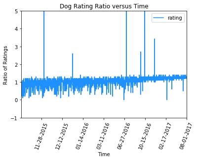

```python
twitter_archive_data.plot(x="date", y="rating", color='dodgerblue')
plt.title('Dog Rating Ratio versus Time')
plt.xlabel('Time')
plt.ylabel('Ratio of Ratings')
plt.xticks(rotation=70)
plt.ylim(-1, 5)
plt.gca().invert_xaxis()
plt.savefig('rating_ratio_time.png')
plt.show()
```

#### Visualization of image prediction accuracy.

-How often image prediction realizes that an image is an image of a dog (if the prediction is a breed of dog, then the image prediction is accurate enough at least to see that a dog is a dog, even if it predicts the wrong species).

-Does the image prediction consistently choose dog or not dog over its three predictions?

```python
is_dog = pd.DataFrame()
is_dog["p1_dog"] = twitter_archive_data["p1_dog"]
is_dog["p2_dog"] = twitter_archive_data["p2_dog"]
is_dog["p3_dog"] = twitter_archive_data["p3_dog"]
```

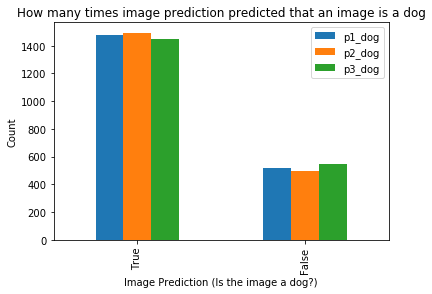

```python
is_dog.apply(pd.value_counts).plot(kind='bar')
plt.title("How many times image prediction predicted that an image is a dog")
plt.xlabel('Image Prediction (Is the image a dog?)')
plt.ylabel('Count')
plt.savefig('image_prediction_counts.png')
plt.show()
```